# Can we predict the burnt area of a forest fire based on spatial, temporal, and weather variables?

Predicting the burnt area of a forest fire based on various attributes is a complex task. This analysis utilizes a dataset containing 517 fires from the Montesinho Natural Park in Portugal. Each record includes the day of the week, month, coordinates, and burnt area, along with several meteorological variables such as rain, temperature, humidity, and wind.

The dataset does not include explicit information about the duration of the fires or firefighting efforts. Thus, we must assume the data reflects the conditions and their impact on the burnt area without these additional details.

**The dataset contains the following attributes:**

**Temporal attributes:**

Month: The month of the year when the fire occurred, represented as categorical values ranging from "jan" to "dec". Day: The day of the week when the fire occurred, represented as categorical values ranging from "mon" to "sun"

**Spatial attributes:**

X: Represents the x-axis spatial coordinate within the Montesinho park map, ranging from 1 to 9.

Y: Represents the y-axis spatial coordinate within the Montesinho park map, ranging from 2 to 9.

**Weather attributes:** FFMC: The Fine Fuel Moisture Code (FFMC) index from the Fire Weather Index (FWI) system, ranging from 18.7 to 96.20. It indicates the moisture content of surface litter and influences the ease of ignition and fire spread.

DMC: The Duff Moisture Code (DMC) index from the FWI system, ranging from 1.1 to 291.3. It represents the moisture content of loosely compacted organic layers and influences fire intensity.

DC: The Drought Code (DC) index from the FWI system, ranging from 7.9 to 860.6. It indicates long-term drying and represents the moisture content of deep, compact organic layers.

ISI: The Initial Spread Index (ISI) from the FWI system, ranging from 0.0 to 56.10. It combines the effects of wind and the FFMC to estimate the rate of fire spread.

temp: The temperature in Celsius degrees, ranging from 2.2 to 33.30.

RH: The relative humidity in percentage, ranging from 15.0 to 100.

Wind: The wind speed in kilometers per hour, ranging from 0.40 to 9.40.

Rain: The amount of rainfall in millimeters per square meter, ranging from 0.0 to 6.4.

**Target variable:**

Area: The burned area of the forest in hectares, ranging from 0.00 to 1090.84. This is the target variable that we aim to predict. A Hectare is equal to 10,000 square meters of land.

```python
import pandas as pd
import numpy as np
import matplotlib.pyplot as plt
import seaborn as sns

import tensorflow as tf
from tensorflow import keras
from tensorflow.keras.models import Sequential, Model
from tensorflow.keras.layers import Dense, Dropout, Input, Add, Activation, Concatenate, BatchNormalization
from tensorflow.keras.optimizers import Adam
from tensorflow.keras.callbacks import EarlyStopping
from tensorflow.keras.regularizers import l2
from tensorflow.keras.utils import plot_model

import keras_tuner as kt

from sklearn.model_selection import train_test_split, KFold
from sklearn.preprocessing import StandardScaler, MinMaxScaler
from sklearn.metrics import mean_squared_error
from sklearn.compose import ColumnTransformer
from sklearn.pipeline import Pipeline

from scikeras.wrappers import KerasRegressor
```

## Exploratory data analysis

```python
df = pd.read_csv("C:/Users/User/Desktop/CS830 Machine learning/Assessment 2/forestfires.csv")
```

```python
print(df.head())
print(df.shape)
```

```
   X  Y month  day  FFMC   DMC     DC  ISI  temp  RH  wind  rain  area
0  7  5   mar  fri  86.2  26.2   94.3  5.1   8.2  51   6.7   0.0   0.0
1  7  4   oct  tue  90.6  35.4  669.1  6.7  18.0  33   0.9   0.0   0.0
2  7  4   oct  sat  90.6  43.7  686.9  6.7  14.6  33   1.3   0.0   0.0
3  8  6   mar  fri  91.7  33.3   77.5  9.0   8.3  97   4.0   0.2   0.0
4  8  6   mar  sun  89.3  51.3  102.2  9.6  11.4  99   1.8   0.0   0.0
(517, 13)
```

```python
df.info()
```

```
<class 'pandas.core.frame.DataFrame'>
RangeIndex: 517 entries, 0 to 516
Data columns (total 13 columns):
 #   Column  Non-Null Count  Dtype
---  ------  --------------  -----
 0   X       517 non-null    int64
 1   Y       517 non-null    int64
 2   month   517 non-null    object
 3   day     517 non-null    object
 4   FFMC    517 non-null    float64
 5   DMC     517 non-null    float64
 6   DC      517 non-null    float64
 7   ISI     517 non-null    float64
 8   temp    517 non-null    float64
 9   RH      517 non-null    int64
 10  wind    517 non-null    float64
 11  rain    517 non-null    float64
 12  area    517 non-null    float64
dtypes: float64(8), int64(3), object(2)
memory usage: 52.6+ KB
```

All columns have 517 non-null counts, indicating there are no missing values in the dataset. There are 11 numerical features (8 float64 and 3 int64) and 2 categorical features ('month' and 'day'), which represent the month of the year and the day of the week, respectively.

```python
display(df.describe())
```

|  | X | Y | FFMC | DMC | DC | ISI | temp | RH | wind | rain | area |
| --- | --- | --- | --- | --- | --- | --- | --- | --- | --- | --- | --- |
| count | 517.000000 | 517.000000 | 517.000000 | 517.000000 | 517.000000 | 517.000000 | 517.000000 | 517.000000 | 517.000000 | 517.000000 | 517.000000 |
| mean | 4.669246 | 4.299807 | 90.644681 | 110.872340 | 547.940039 | 9.021663 | 18.889168 | 44.288201 | 4.017602 | 0.021663 | 12.847292 |
| std | 2.313778 | 1.229900 | 5.520111 | 64.046482 | 248.066192 | 4.559477 | 5.806625 | 16.317469 | 1.791653 | 0.295959 | 63.655818 |
| min | 1.000000 | 2.000000 | 18.700000 | 1.100000 | 7.900000 | 0.000000 | 2.200000 | 15.000000 | 0.400000 | 0.000000 | 0.000000 |
| 25% | 3.000000 | 4.000000 | 90.200000 | 68.600000 | 437.700000 | 6.500000 | 15.500000 | 33.000000 | 2.700000 | 0.000000 | 0.000000 |
| 50% | 4.000000 | 4.000000 | 91.600000 | 108.300000 | 664.200000 | 8.400000 | 19.300000 | 42.000000 | 4.000000 | 0.000000 | 0.520000 |
| 75% | 7.000000 | 5.000000 | 92.900000 | 142.400000 | 713.900000 | 10.800000 | 22.800000 | 53.000000 | 4.900000 | 0.000000 | 6.570000 |
| max | 9.000000 | 9.000000 | 96.200000 | 291.300000 | 860.600000 | 56.100000 | 33.300000 | 100.000000 | 9.400000 | 6.400000 | 1090.840000 |

Looking at the numerical features in more detail, the spatial coordinates (X and Y) range from 1 to 9 and 2 to 9, respectively, covering a limited geographical area. Environmental factors such as the Fine Fuel Moisture Code (FFMC), Duff Moisture Code (DMC), and Drought Code (DC) show significant variability, indicating diverse conditions that influence fire behavior. FFMC values are generally high, suggesting dry conditions favorable for fire spread. DMC and DC values span a wide range, reflecting varied moisture levels and drought severity. The Initial Spread Index (ISI) also varies significantly, indicating different initial fire spread rates. The average temperature is 18.89°C, with a broad range from 2.2°C to 33.3°C, suggesting both cold and hot days. Relative humidity ranges from 15% to 100%, affecting fire dynamics. Wind speeds are generally low, averaging 4.02 km/h, but can occasionally reach moderate levels, influencing fire spread. Rainfall is minimal, with an average of 0.02 mm, indicating generally dry conditions. The burned area has a high standard deviation, with most fires being small but some reaching up to 1090.84 ha. This variability highlights the diverse fire behaviors and environmental conditions present in the dataset, which will be critical for modeling and prediction efforts.

```python
missing_values = df.isnull().sum()
print("Missing values:\n", missing_values)
```

```
Missing values:
 X        0
Y        0
month    0
day      0
FFMC     0
DMC      0
DC       0
ISI      0
temp     0
RH       0
wind     0
rain     0
area     0
dtype: int64
```

There are no missing values.

```python
duplicates = df.duplicated()
num_duplicates = duplicates.sum()
print(f'Number of duplicate rows: {num_duplicates}')
```

```
Number of duplicate rows: 4
```

```python
if num_duplicates > 0:
    print('Duplicate rows:')
    print(df[duplicates])
```

```
Duplicate rows:
     X  Y month  day  FFMC    DMC     DC   ISI  temp  RH  wind  rain   area
53   4  3   aug  wed  92.1  111.2  654.1   9.6  20.4  42   4.9   0.0   0.00
100  3  4   aug  sun  91.4  142.4  601.4  10.6  19.8  39   5.4   0.0   0.00
215  4  4   mar  sat  91.7   35.8   80.8   7.8  17.0  27   4.9   0.0  28.66
303  3  6   jun  fri  91.1   94.1  232.1   7.1  19.2  38   4.5   0.0   0.00
```

## Data Visualisation and Exploration

Categorical and numerical features are listed and defined. This distinction is essential for subsequent preprocessing steps, where categorical and numerical features may be treated differently to prepare the data for modelling.

```python
categorical_features = ['month', 'day']
numerical_features = ['temp', 'RH', 'wind', 'rain', 'FFMC', 'DMC', 'DC', 'ISI', 'X', 'Y', 'area']
```

### Numerical variables

The code below creates a grid of histograms to visualize the distribution of each numerical feature in the dataset. This helps in understanding the spread and shape of the data for each feature, which is crucial for identifying patterns, skewness, and potential outliers.

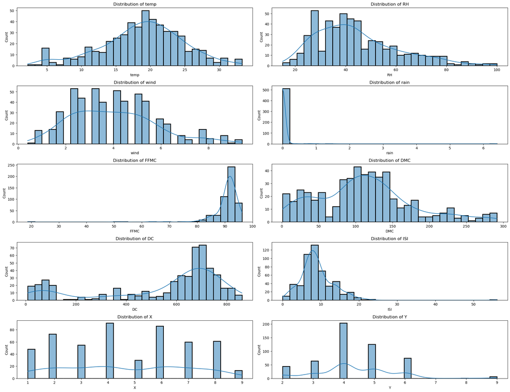

```python
numerical_features_excluding_area = [feature for feature in numerical_features if feature != 'area']

n_rows = 6
n_cols = 2

plt.figure(figsize=(20, 18))
for i, feature in enumerate(numerical_features_excluding_area):
    plt.subplot(n_rows, n_cols, i + 1)
    sns.histplot(df[feature], kde=True, bins=30, edgecolor="black", linewidth=2)
    plt.title(f'Distribution of {feature}')
plt.tight_layout()
plt.show()
```

The data distribution of the features reveals distinct patterns. Temperature values are normally distributed, primarily between 15 and 25 degrees Celsius. Relative humidity is right-skewed, with most observations ranging from 20% to 50%. Wind speed distribution is roughly uniform, with a noticeable peak around 4 m/s. Rainfall is heavily right-skewed, with most days having no rain. The Fine Fuel Moisture Code (FFMC) is left-skewed, with values mostly above 85, indicating dry conditions. The Duff Moisture Code (DMC) shows a slight right skew, with most values between 40 and 150. Drought Code (DC) is left-skewed, with many values above 300, suggesting prolonged dry conditions. The Initial Spread Index (ISI) is right-skewed, with most values below 10, indicating rare rapid fire spread conditions. The X-coordinate values are uniformly distributed, while the Y-coordinate values show variability, with peaks around certain values, indicating potential fire hotspots.

### Categorical variables

Looking at the categorical variables in more detail to get a better understanding of their distribution. Days and months are ordered to maintain consistency when visualising.

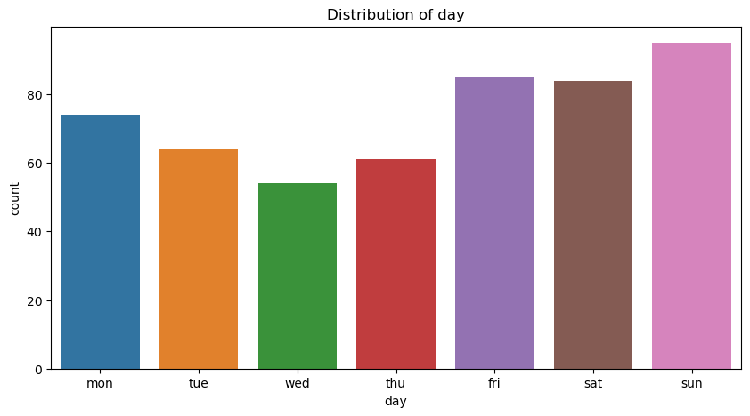

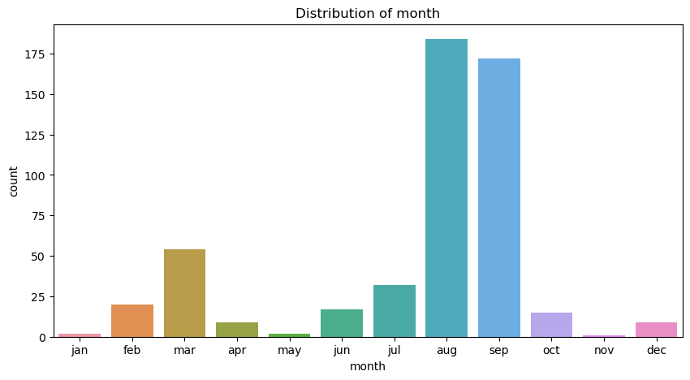

```python
day_order = ['mon', 'tue', 'wed', 'thu', 'fri', 'sat', 'sun']
month_order = ['jan', 'feb', 'mar', 'apr', 'may', 'jun', 'jul', 'aug', 'sep', 'oct', 'nov', 'dec']

categorical_features = {
    'day': day_order,
    'month': month_order
}

for feature, order in categorical_features.items():
    plt.figure(figsize=(10, 5))
    sns.countplot(data=df, x=feature, order=order)
    plt.title(f'Distribution of {feature}')
    plt.show()
```

The bar chart for the month variable reveals that forest fires are most frequent in August and September, followed by March, indicating a strong seasonal pattern. These months, particularly late summer to early autumn, experience significantly higher fire occurrences, likely due to favorable climatic conditions such as higher temperatures and lower humidity. In contrast, the winter months (January, February, December) and other months like April, June, May, and November show significantly fewer fires. This suggests that fire prevention and preparedness efforts should be intensified during high-risk periods (August, September, and March) to mitigate the impact of forest fires.

The bar chart for the day variable indicates that forest fires are most frequent on Sundays and Fridays, followed by Saturdays and Mondays. This pattern suggests an increased risk of fires during the weekend, likely due to heightened human activity. Conversely, mid-week days (Tuesday, Wednesday, and Thursday) have fewer fire incidents, with Wednesday showing the least. These insights highlight the need for enhanced fire prevention measures and resource allocation towards the end of the week and over the weekend to effectively mitigate the risk of forest fires.

### Target Variable

Looking at the target area in more detail allows for a better understanding of the distribution.

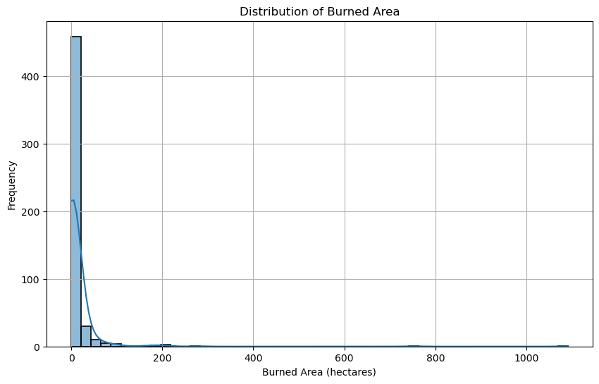

```python
plt.figure(figsize=(10, 6))
sns.histplot(df['area'], bins=50, kde=True, edgecolor="black", linewidth=1.2)
plt.title('Distribution of Burned Area')
plt.xlabel('Burned Area (hectares)')
plt.ylabel('Frequency')
plt.grid(True)
plt.show()
```

The burned area is heavily right-skewed, with most values close to zero, and a few significant outliers, suggesting that most fires are small, but there are occasional large fires.

```python
zero_count = (df['area'] == 0).sum()

print(f"Number of 0 values in the 'area' column: {zero_count}")
```

```
Number of 0 values in the 'area' column: 247
```

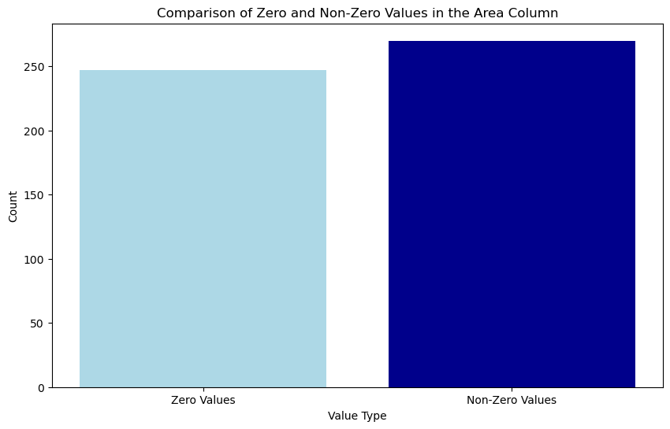

```python
zero_count = (df['area'] == 0).sum()
non_zero_count = (df['area'] != 0).sum()


counts = [zero_count, non_zero_count]
labels = ['Zero Values', 'Non-Zero Values']


plt.figure(figsize=(10, 6))
plt.bar(labels, counts, color=['lightblue', 'darkblue'])
plt.title('Comparison of Zero and Non-Zero Values in the Area Column')
plt.xlabel('Value Type')
plt.ylabel('Count')
plt.show()
```

Almost 50% of the target variable has 0 values meaning the area burned was less than one hectare of land causing the distribution to be heavily right skewed. A log transformation might help in normalising the distribution.

Creating a heatmap to help visualise area burned by X and Y Coordinates

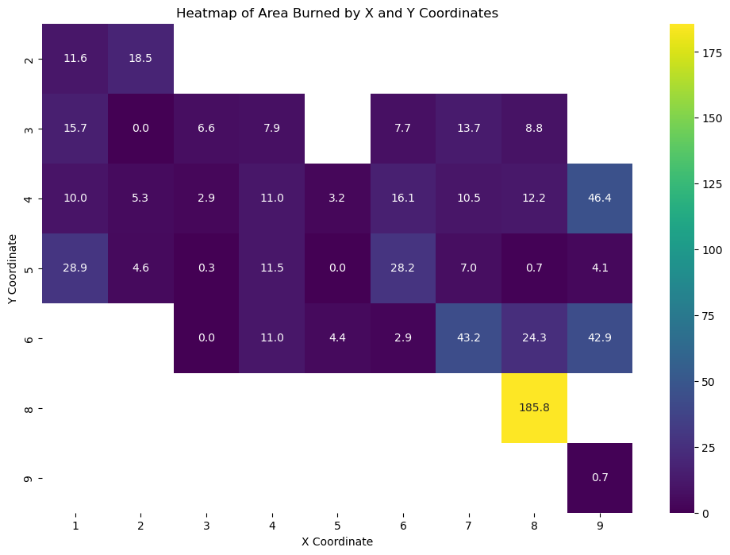

```python
heatmap_data = df.pivot_table(values='area', index='Y', columns='X', aggfunc='mean')


plt.figure(figsize=(12, 8))
sns.heatmap(heatmap_data, annot=True, fmt='.1f', cmap='viridis')
plt.title('Heatmap of Area Burned by X and Y Coordinates')
plt.xlabel('X Coordinate')
plt.ylabel('Y Coordinate')
plt.show()
```

### Relationships between variables

Generating scatter plots can be beneficial to visualize the relationship between each numerical feature (excluding 'area') and the target variable 'area'. The purpose is to identify potential patterns, correlations, or insights that could inform model building.

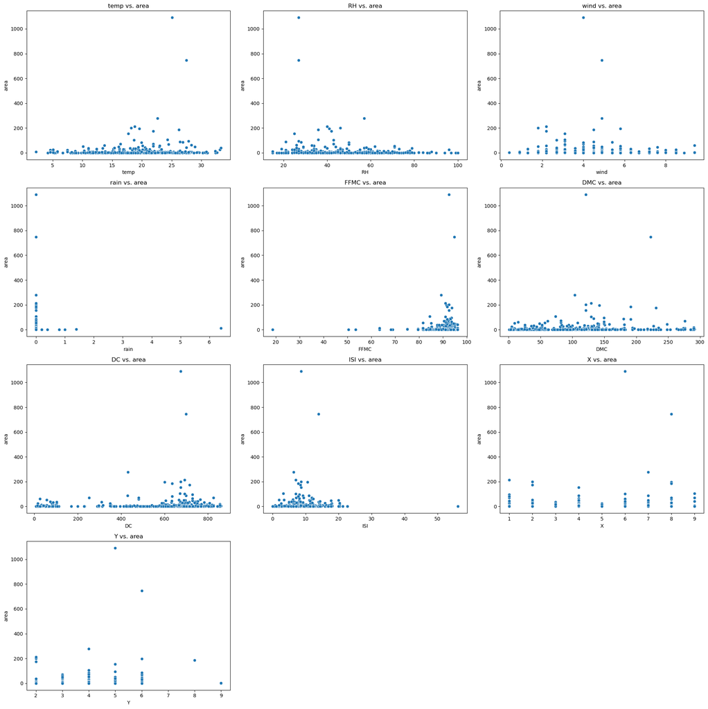

```python
features_to_plot = numerical_features[:-1]


plt.figure(figsize=(20, 20))


for i, feature in enumerate(features_to_plot):
    plt.subplot(4, 3, i+1)
    sns.scatterplot(data=df, x=feature, y='area')
    plt.title(f'{feature} vs. area')

plt.tight_layout()
plt.show()
```

The scatter plots generated show the relationship between various numerical features and the target variable 'area'.

The relationships between the features and the target variable 'area' do not appear to be linear. This suggests that linear models might not be very effective, and non-linear models might be more appropriate.

There are some clear outliers, especially in the 'area' variable, where a few data points have very high values compared to the rest. These outliers can significantly affect model performance and might need special handling.

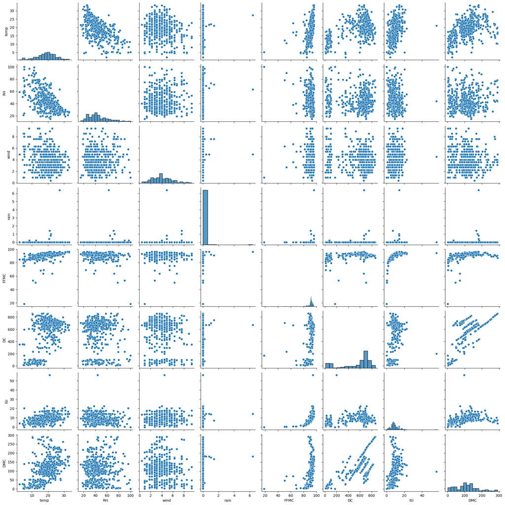

```python
selected_features = ['temp', 'RH', 'wind', 'rain', 'FFMC', 'DC', 'ISI', 'DMC']
sns.pairplot(df[selected_features])
plt.show()
```

The pair plot reveals several key insights about the relationships between the numerical features in the dataset. Temperature and relative humidity exhibit a negative correlation, indicating that higher temperatures are associated with lower humidity levels. The rainfall feature is highly skewed with many zero values, reflecting the rarity of significant rainfall events.

The Drought Code (DC) is positively correlated with DMC, indicating that prolonged dry conditions result in reduced moisture in the duff layer. Wind speed, however, displays a uniform distribution and lacks strong correlations with other features, suggesting its relative independence from other variables.

Plotting the average area burned, temperature, rainfall and windspeed for categorical variables, such as days and months, helps visualize the distribution and frequency more effectively. To achieve a simpler and more interpretable visualization, the days and months are first ordered correctly. Then, the data is grouped to calculate the mean for each day and month.

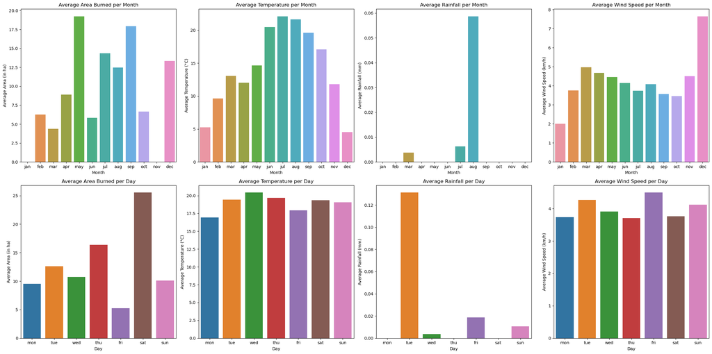

```python
df['day'] = pd.Categorical(df['day'], categories=day_order, ordered=True)
df['month'] = pd.Categorical(df['month'], categories=month_order, ordered=True)

# Group by 'month' and calculate the means
avg_metrics_per_month = df.groupby('month').agg({'area': 'mean', 'temp': 'mean', 'rain': 'mean', 'wind': 'mean'}).reset_index()

# Group by 'day' and calculate the means
avg_metrics_per_day = df.groupby('day').agg({'area': 'mean', 'temp': 'mean', 'rain': 'mean', 'wind': 'mean'}).reset_index()

# Create subplots in a 2x4 grid
fig, axes = plt.subplots(2, 4, figsize=(24, 12))

# Plot average area burned per month
sns.barplot(data=avg_metrics_per_month, x='month', y='area', order=month_order, ax=axes[0, 0])
axes[0, 0].set_title('Average Area Burned per Month')
axes[0, 0].set_xlabel('Month')
axes[0, 0].set_ylabel('Average Area (in ha)')

# Plot average temperature per month
sns.barplot(data=avg_metrics_per_month, x='month', y='temp', order=month_order, ax=axes[0, 1])
axes[0, 1].set_title('Average Temperature per Month')
axes[0, 1].set_xlabel('Month')
axes[0, 1].set_ylabel('Average Temperature (°C)')

# Plot average rainfall per month
sns.barplot(data=avg_metrics_per_month, x='month', y='rain', order=month_order, ax=axes[0, 2])
axes[0, 2].set_title('Average Rainfall per Month')
axes[0, 2].set_xlabel('Month')
axes[0, 2].set_ylabel('Average Rainfall (mm)')

# Plot average wind speed per month
sns.barplot(data=avg_metrics_per_month, x='month', y='wind', order=month_order, ax=axes[0, 3])
axes[0, 3].set_title('Average Wind Speed per Month')
axes[0, 3].set_xlabel('Month')
axes[0, 3].set_ylabel('Average Wind Speed (km/h)')

# Plot average area burned per day
sns.barplot(data=avg_metrics_per_day, x='day', y='area', order=day_order, ax=axes[1, 0])
axes[1, 0].set_title('Average Area Burned per Day')
axes[1, 0].set_xlabel('Day')
axes[1, 0].set_ylabel('Average Area (in ha)')

# Plot average temperature per day
sns.barplot(data=avg_metrics_per_day, x='day', y='temp', order=day_order, ax=axes[1, 1])
axes[1, 1].set_title('Average Temperature per Day')
axes[1, 1].set_xlabel('Day')
axes[1, 1].set_ylabel('Average Temperature (°C)')

# Plot average rainfall per day
sns.barplot(data=avg_metrics_per_day, x='day', y='rain', order=day_order, ax=axes[1, 2])
axes[1, 2].set_title('Average Rainfall per Day')
axes[1, 2].set_xlabel('Day')
axes[1, 2].set_ylabel('Average Rainfall (mm)')

# Plot average wind speed per day
sns.barplot(data=avg_metrics_per_day, x='day', y='wind', order=day_order, ax=axes[1, 3])
axes[1, 3].set_title('Average Wind Speed per Day')
axes[1, 3].set_xlabel('Day')
axes[1, 3].set_ylabel('Average Wind Speed (km/h)')

plt.tight_layout()
plt.show()
```

The average area burned per month shows significant variation, with May having the highest average area burned, followed by September and July, while November has the lowest. Similarly, the average area burned per day also varies noticeably, with Saturday experiencing the highest average area burned by a significant margin, possibly due to human activity and Friday the lowest. These patterns highlight the variability in fire activity across different times of the year and days of the week.

Additionally July and August are the hottest months, correlating with increased fire risks. August also experiences exceptionally high rainfall, which could influence fire patterns. Tuesday appears to be a day when rainfall is considerably high also. Wind speeds are highest in December and March, with Tuesday and Friday having the highest weekly wind speeds. These patterns help identify high-risk periods for targeted fire prevention and control strategies.

Multicollinearity refers to the presence of high correlations among the independent variables in a dataset. This can lead to unstable estimates of the model parameters, inflate the standard errors, and reduce the overall interpretability of the model. To address this issue we can generate a correlation matrix, which provides a comprehensive view of the pairwise relationships between all variables.

By examining the correlation matrix, we can identify highly correlated pairs of features that might contribute to multicollinearity.

```python
corr_matrix = df[numerical_features].corr()
```

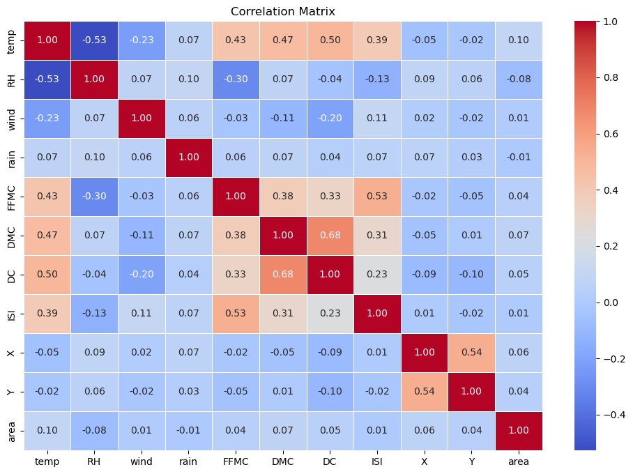

```python
plt.figure(figsize=(12, 8))
sns.heatmap(corr_matrix, annot=True, cmap='coolwarm', fmt='.2f', linewidths=0.5)
plt.title('Correlation Matrix')
plt.show()
```

There is a moderate positive correlation between temperature and the Drought Code, indicating that higher temperatures tend to be associated with higher drought code values. Temperature also shows a moderate positive correlation with the Duff Moisture Code, suggesting that higher temperatures are related to higher DMC values. There is a moderate positive correlation between temperature and the Fine Fuel Moisture Code. The Fine Fuel Moisture Code is moderately positively correlated with the Initial Spread Index. There is a strong positive correlation between Duff Moisture Code and Drought Code, indicating that these two indices tend to increase together. There is a moderate positive correlation between the X and Y spatial coordinates, suggesting some clustering in certain regions.

The target variable, area, does not show strong correlations with any of the predictors.

## Data transformation

Deep learning models, such as neural networks, can generally handle outliers and skewed data better than traditional machine learning models because of their inherent capacity to learn complex patterns in the data. However it is still prudent to ensure data is normalised to ensure optimal performance.

As area is heavily right skewed with many values being 0.00 then it is helpful to log-transform the variables to reduce the skewness

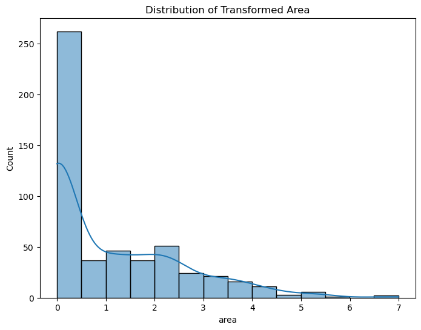

```python
df['area'] = np.log1p(df['area'])


plt.figure(figsize=(8, 6))
sns.histplot(df['area'], kde=True)
plt.title('Distribution of Transformed Area')
plt.show()
```

The transformed distribution of the area variable, as shown in the histogram, indicates that the log transformation has successfully reduced some of the skewness, but the distribution is still somewhat right-skewed with a large number of zero or near-zero values.

Boxplots can be helpful in visualising outliers.

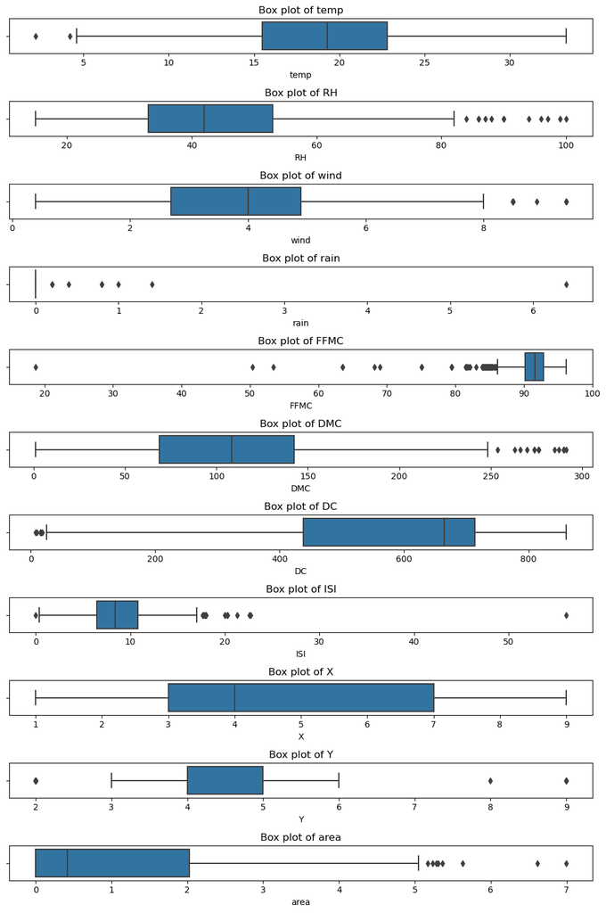

```python
fig, axes = plt.subplots(nrows=len(numerical_features), ncols=1, figsize=(10, 15))


for i, feature in enumerate(numerical_features):
    sns.boxplot(x=df[feature], ax=axes[i], orient='h')
    axes[i].set_title(f'Box plot of {feature}')


plt.tight_layout()
plt.show()
```

```python
Q1 = df[numerical_features].quantile(0.25)
Q3 = df[numerical_features].quantile(0.75)
IQR = Q3 - Q1


outlier_criteria = ((df[numerical_features] < (Q1 - 1.5 * IQR)) | (df[numerical_features] > (Q3 + 1.5 * IQR)))


outlier_counts_iqr = outlier_criteria.sum()


outlier_counts_iqr_df = pd.DataFrame({'Feature': numerical_features, 'Outlier_Count_IQR': outlier_counts_iqr})
print(outlier_counts_iqr_df)
```

```
     Feature  Outlier_Count_IQR
temp    temp                  2
RH        RH                 12
wind    wind                 13
rain    rain                  8
FFMC    FFMC                 53
DMC      DMC                 17
DC        DC                  8
ISI      ISI                 23
X          X                  0
Y          Y                 51
area    area                  8
```

Given that there are 195 outliers out of 517 data points, removing all of them would result in a significant loss of data. In such cases, it's often better to handle outliers in ways that mitigate their impact without discarding too much data. Such strategies can include capping extreme valeus to a certain percentile, using scaling techniques and modelling with algorithms that are robust to outliers.

Next we can transform the months and days to numerical values as most machine learning algorithms such as neural networks, work better with numerical data. First we map the numbers to the months then apply this to the month column before following the same process to the days column.

```python
month_mapping = {
    'jan': 1, 'feb': 2, 'mar': 3, 'apr': 4, 'may': 5, 'jun': 6,
    'jul': 7, 'aug': 8, 'sep': 9, 'oct': 10, 'nov': 11, 'dec': 12
}


df['month'] = df['month'].map(month_mapping)


day_mapping = {
    'mon': 1, 'tue': 2, 'wed': 3, 'thu': 4, 'fri': 5, 'sat': 6, 'sun': 7
}


df['day'] = df['day'].map(day_mapping)

# Check the transformation
print(df.head())
```

```
   X  Y  month  day  FFMC   DMC     DC  ISI  temp  RH  wind  rain  area
0  7  5      3    5  86.2  26.2   94.3  5.1   8.2  51   6.7   0.0   0.0
1  7  4     10    2  90.6  35.4  669.1  6.7  18.0  33   0.9   0.0   0.0
2  7  4     10    6  90.6  43.7  686.9  6.7  14.6  33   1.3   0.0   0.0
3  8  6      3    5  91.7  33.3   77.5  9.0   8.3  97   4.0   0.2   0.0
4  8  6      3    7  89.3  51.3  102.2  9.6  11.4  99   1.8   0.0   0.0
```

# Training a simple neural network as a baseline

When building neural networks it is important to start with a simple model to act as a baseline. We will use packages such as Pandas and Numpy for data manipulation, Matplotlib and Seaborn for visualization. Tensorflow and Keras will be used for building neural networks while Scikit-learn used for data preprocessing and metrics.

The following code defines the features and target variable from our data frame by separating the 'area' column as the target (y) and the rest of the columns as features (X).

We then split the data into training, validation, and test sets using an 80-20% split for both training and testing, and an additional 80-20% split within the training set to create a validation set.

```python
X = df.drop('area', axis=1)
y = df['area']

X_train_full, X_test, y_train_full, y_test = train_test_split(X, y, test_size=0.2, random_state=42)
X_train, X_valid, y_train, y_valid = train_test_split(X_train_full, y_train_full, test_size=0.2, random_state=42)
```

Standard Scaler was chosen to ensure that all input features are on the same scale, with a mean of zero and a standard deviation of one. This standardization is crucial as it helps to stabilize and speed up the training process by ensuring that the gradients do not fluctuate too much. By scaling the features, the model can learn more effectively and converge faster, which is particularly important given the diverse range of values in the dataset's features. Standardization also helps in reducing the bias caused by features with larger scales, leading to more balanced weight updates during training.

```python
scaler = StandardScaler()
X_train = scaler.fit_transform(X_train)
X_valid = scaler.transform(X_valid)
X_test = scaler.transform(X_test)
```

```python
display(df.describe())
```

|  | X | Y | month | day | FFMC | DMC | DC | ISI | temp | RH | wind | rain | area |
| --- | --- | --- | --- | --- | --- | --- | --- | --- | --- | --- | --- | --- | --- |
| count | 517.000000 | 517.000000 | 517.000000 | 517.000000 | 517.000000 | 517.000000 | 517.000000 | 517.000000 | 517.000000 | 517.000000 | 517.000000 | 517.000000 | 517.000000 |
| mean | 4.669246 | 4.299807 | 7.475822 | 4.259188 | 90.644681 | 110.872340 | 547.940039 | 9.021663 | 18.889168 | 44.288201 | 4.017602 | 0.021663 | 1.111026 |
| std | 2.313778 | 1.229900 | 2.275990 | 2.072929 | 5.520111 | 64.046482 | 248.066192 | 4.559477 | 5.806625 | 16.317469 | 1.791653 | 0.295959 | 1.398436 |
| min | 1.000000 | 2.000000 | 1.000000 | 1.000000 | 18.700000 | 1.100000 | 7.900000 | 0.000000 | 2.200000 | 15.000000 | 0.400000 | 0.000000 | 0.000000 |
| 25% | 3.000000 | 4.000000 | 7.000000 | 2.000000 | 90.200000 | 68.600000 | 437.700000 | 6.500000 | 15.500000 | 33.000000 | 2.700000 | 0.000000 | 0.000000 |
| 50% | 4.000000 | 4.000000 | 8.000000 | 5.000000 | 91.600000 | 108.300000 | 664.200000 | 8.400000 | 19.300000 | 42.000000 | 4.000000 | 0.000000 | 0.418710 |
| 75% | 7.000000 | 5.000000 | 9.000000 | 6.000000 | 92.900000 | 142.400000 | 713.900000 | 10.800000 | 22.800000 | 53.000000 | 4.900000 | 0.000000 | 2.024193 |
| max | 9.000000 | 9.000000 | 12.000000 | 7.000000 | 96.200000 | 291.300000 | 860.600000 | 56.100000 | 33.300000 | 100.000000 | 9.400000 | 6.400000 | 6.995620 |

In this model, straightforward neural network architecture is utilised to predict the burned area of forest fires based on various spatial, temporal, and meteorological features. The model is built using the Sequential API from Keras, which allows us to stack layers sequentially.

We start by defining an input layer that takes in data with the same shape as our training features. This is followed by a single Dense layer, which acts as the output layer, containing one neuron. The absence of an activation function in this Dense layer means it uses a linear activation by default, making it suitable for regression tasks. This linear model directly maps the input features to the target variable, predicting the burned area. While this simple architecture might suffice for linear relationships, it may not capture more complex patterns present in the data. Therefore, it serves as a baseline model, providing a fundamental benchmark for comparison against more sophisticated models.

```python
model = Sequential()
model.add(Input(shape=X_train.shape[1:]))
model.add(Dense(1))
```

Next we configure the model for training by specifying the loss function and the optimization algorithm. The mean_squared_error (MSE) loss function measures the average squared differences between the predicted and actual values, making it suitable for regression tasks where the goal is to predict continuous values. The sgd (Stochastic Gradient Descent) optimizer iteratively updates the model's weights to minimize the loss function. By combining MSE with SGD, the model aims to achieve accurate predictions by reducing the average prediction error and efficiently adjusting the weights during training.

```python
model.compile(loss="mean_squared_error", optimizer="sgd")
```

Now we can train the neural network model using the training data. The model will be trained for 20 epochs, meaning the entire training dataset is passed through the model 20 times. The validation_data parameter allows the model to be evaluated on a separate validation set after each epoch, helping to monitor the model's performance and prevent overfitting. The training process records various metrics and loss values at each epoch, which are stored in the history object for further analysis and visualization.

```python
history = model.fit(X_train, y_train, epochs=20, validation_data=(X_valid, y_valid))
```

```
11/11 ━━━━━━━━━━━━━━━━━━━━ 3s 61ms/step - loss: 5.6984 - val_loss: 6.6301
11/11 ━━━━━━━━━━━━━━━━━━━━ 0s 8ms/step - loss: 4.1762 - val_loss: 6.2692
11/11 ━━━━━━━━━━━━━━━━━━━━ 0s 11ms/step - loss: 3.0356 - val_loss: 6.2040
11/11 ━━━━━━━━━━━━━━━━━━━━ 0s 4ms/step - loss: 3.2665 - val_loss: 6.2067
11/11 ━━━━━━━━━━━━━━━━━━━━ 0s 4ms/step - loss: 2.3240 - val_loss: 6.3822
11/11 ━━━━━━━━━━━━━━━━━━━━ 0s 4ms/step - loss: 2.4205 - val_loss: 6.4688
11/11 ━━━━━━━━━━━━━━━━━━━━ 0s 4ms/step - loss: 2.3260 - val_loss: 6.5766
11/11 ━━━━━━━━━━━━━━━━━━━━ 0s 5ms/step - loss: 2.2093 - val_loss: 6.5601
11/11 ━━━━━━━━━━━━━━━━━━━━ 0s 4ms/step - loss: 2.0116 - val_loss: 6.5940
11/11 ━━━━━━━━━━━━━━━━━━━━ 0s 5ms/step - loss: 2.0112 - val_loss: 6.5645
11/11 ━━━━━━━━━━━━━━━━━━━━ 0s 13ms/step - loss: 1.9339 - val_loss: 6.7125
11/11 ━━━━━━━━━━━━━━━━━━━━ 0s 5ms/step - loss: 2.0534 - val_loss: 6.6933
11/11 ━━━━━━━━━━━━━━━━━━━━ 0s 4ms/step - loss: 2.0579 - val_loss: 6.4886
11/11 ━━━━━━━━━━━━━━━━━━━━ 0s 5ms/step - loss: 2.1348 - val_loss: 5.3073
11/11 ━━━━━━━━━━━━━━━━━━━━ 0s 4ms/step - loss: 2.0092 - val_loss: 5.4870
11/11 ━━━━━━━━━━━━━━━━━━━━ 0s 6ms/step - loss: 1.8277 - val_loss: 5.5667
11/11 ━━━━━━━━━━━━━━━━━━━━ 0s 9ms/step - loss: 1.8088 - val_loss: 5.6937
11/11 ━━━━━━━━━━━━━━━━━━━━ 0s 6ms/step - loss: 2.1074 - val_loss: 5.7874
11/11 ━━━━━━━━━━━━━━━━━━━━ 0s 5ms/step - loss: 1.9917 - val_loss: 5.8156
11/11 ━━━━━━━━━━━━━━━━━━━━ 0s 4ms/step - loss: 2.1742 - val_loss: 5.7508
```

During training, the output shows the loss for both the training and validation sets at each epoch, indicating how well the model is fitting the data.

The next steps involve evaluating the trained model and making predictions on new data. First, the model is evaluated on the test set using the evaluate method, which computes the mean squared error (MSE) between the predicted and actual values for the test data, providing an indication of how well the model generalizes to unseen data. The test MSE is then printed. Following the evaluation, the model makes predictions on new data points.

The first three samples from the test set (X_test[:3]) are used for predictions. The predict method generates the predicted values for these samples, which are then printed. These steps help in assessing the model's performance and its ability to make accurate predictions on new, unseen data.

```python
mse_test = model.evaluate(X_test, y_test)
print(f"Test MSE: {mse_test}")

X_new = X_test[:3]
y_pred = model.predict(X_new)
print(f"Predictions: {y_pred}")
```

```
4/4 ━━━━━━━━━━━━━━━━━━━━ 0s 21ms/step - loss: 2.0969
Test MSE: 2.2932238578796387
1/1 ━━━━━━━━━━━━━━━━━━━━ 0s 212ms/step
Predictions: [[ 1.5461072]
 [-0.6638019]
 [ 1.494423 ]]
```

The model demonstrated a test MSE of 2.29 which provides a metric for its prediction accuracy on new data. Additionally, predictions were made for three samples from the test set, yielding values that represent the model's estimates for the burnt area.

```
4/4 ━━━━━━━━━━━━━━━━━━━━ 0s 1ms/step
```

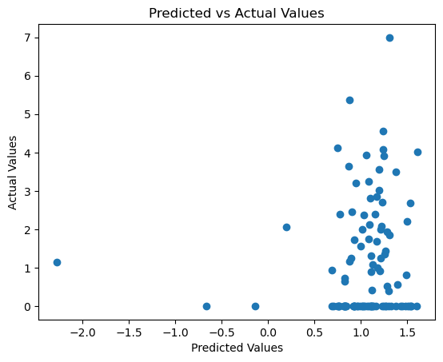

```python
y_pred = model.predict(X_test)
plt.scatter(y_pred, y_test)
plt.xlabel("Predicted Values")
plt.ylabel("Actual Values")
plt.title("Predicted vs Actual Values")
plt.show()
```

The scatter plot shows the predicted values on the x-axis and the actual values on the y-axis. Ideally, the points should lie along a diagonal line, indicating that the predictions are close to the actual values.

The predicted values are largely concentrated around 1, with significant deviations including some negative predictions. The actual values have a wider spread, showing that the model struggles to predict values accurately across the range.

The presence of negative predicted values indicates that the model has not learned the relationship between the features and the target variable well, as the area burned should not be negative.

The model has poor predictive performance. It fails to capture the variability in the actual data, which is evident from the scatter of points away from the diagonal line (which would represent perfect predictions). The concentration of predicted values around 1 suggests that the model is biased towards predicting a value close to the mean of the training data, rather than learning the underlying patterns.

The code below is used to visualize the training history of a neural network model, specifically showing the loss over each epoch during training and validation.

```
        loss  val_loss
0   5.457975  6.630126
1   3.821166  6.269249
2   3.169576  6.203996
3   2.802328  6.206706
4   2.563246  6.382227
5   2.392306  6.468754
6   2.272643  6.576607
7   2.193387  6.560114
8   2.136735  6.594035
9   2.093056  6.564481
10  2.070046  6.712549
11  2.047707  6.693297
12  2.029843  6.488558
13  2.019583  5.307263
14  2.002825  5.487036
15  1.993708  5.566718
16  1.989423  5.693744
17  1.984579  5.787435
18  1.977944  5.815593
19  1.974203  5.750834
```

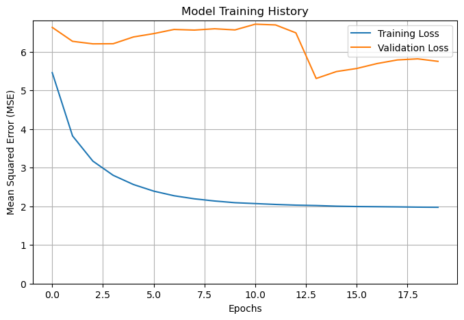

```python
history_df = pd.DataFrame(history.history)
print(history_df)

history_df[['loss', 'val_loss']].plot(figsize=(8, 5))
plt.grid(True)
plt.gca().set_ylim(0, max(history_df[['loss', 'val_loss']].max() + 0.1))
plt.title("Model Training History")
plt.xlabel("Epochs")
plt.ylabel("Mean Squared Error (MSE)")
plt.legend(["Training Loss", "Validation Loss"])
plt.show()
```

The line plot shows the training loss and validation loss over the epochs. The training loss decreases steadily over the epochs, indicating that the model is learning and fitting the training data better over time.

The validation loss, however, remains high and fluctuates, indicating that the model is not generalizing well to unseen data. The gap between the training and validation loss suggests overfitting, where the model performs well on the training data but poorly on the validation data.

## Improved model 1

This time MinMaxScaler will be used. This scales features to a range between 0 and 1 then normalise the entire dataset first and then splits it into training and testing sets.

The choice between MinMaxScaler and StandardScaler can impact the training of the model. MinMaxScaler scales the features to a fixed range, which can be beneficial if the features have different units or scales. StandardScaler centers the data around 0 with a standard deviation of 1, which can be useful for algorithms that assume or perform better with normally distributed data.

```python
X = df.drop('area', axis=1)
y = df['area']

scaler = MinMaxScaler()
X_scaled = scaler.fit_transform(X)

X_train, X_test, y_train, y_test = train_test_split(X_scaled, y, test_size=0.2, random_state=42)
```

An improved model can be built with dropout to further prevent overfitting by randomly setting a fraction of input units to 0 at each update during training. L2 regularization helps to reduce overfitting by penalizing large weights.

While neural networks have some capacity to handle multicollinearity, due to their ability to learn complex relationships, L2 regularization can also help mitigate the effects of multicollinearity which is evident within the data by encouraging the model to keep the weights small.

The first dense layer consists of 64 neurons with ReLU activation for hidden layers and L2 regularization.

The dropout layer has a 50% dropout rate to prevent overfitting. The next dense layer contains 32 neurons with ReLU activation and L2 regularization. The dropout layer is once again 50%. The final layer has an output of 1 neuron with linear activation for regression output.

The model is trained using the Adam optimizer instead of sgd and mean squared error (MSE) loss function. Adam optimizer is an extension of stochastic gradient descent that computes adaptive learning rates for each parameter. It can typically achieve faster convergence compared to other optimization algorithms,

Early stopping is used to prevent overfitting, with patience set to 5 epochs, meaning the training stops if the validation loss does not improve for 5 consecutive epochs

```python
def build_improved_model():
    model = Sequential()
    model.add(Dense(64, input_dim=X_train.shape[1], activation='relu', kernel_regularizer=l2(0.001)))
    model.add(Dropout(0.5))
    model.add(Dense(32, activation='relu', kernel_regularizer=l2(0.001)))
    model.add(Dropout(0.5))
    model.add(Dense(1, activation='linear'))
    model.compile(optimizer='adam', loss='mean_squared_error')
    return model

improved_model = build_improved_model()


early_stopping = EarlyStopping(monitor='val_loss', patience=5, restore_best_weights=True)


history = improved_model.fit(X_train, y_train, epochs=100, batch_size=32, validation_split=0.2,
                             callbacks=[early_stopping], verbose=1)
```

```
11/11 ━━━━━━━━━━━━━━━━━━━━ 4s 81ms/step - loss: 2.7247 - val_loss: 1.6448
11/11 ━━━━━━━━━━━━━━━━━━━━ 0s 7ms/step - loss: 2.8206 - val_loss: 1.5235
11/11 ━━━━━━━━━━━━━━━━━━━━ 0s 5ms/step - loss: 2.4026 - val_loss: 1.5083
11/11 ━━━━━━━━━━━━━━━━━━━━ 0s 6ms/step - loss: 2.1512 - val_loss: 1.5029
11/11 ━━━━━━━━━━━━━━━━━━━━ 0s 5ms/step - loss: 2.1825 - val_loss: 1.5033
11/11 ━━━━━━━━━━━━━━━━━━━━ 0s 5ms/step - loss: 2.1191 - val_loss: 1.5065
11/11 ━━━━━━━━━━━━━━━━━━━━ 0s 5ms/step - loss: 2.3313 - val_loss: 1.5019
11/11 ━━━━━━━━━━━━━━━━━━━━ 0s 5ms/step - loss: 2.3127 - val_loss: 1.5061
11/11 ━━━━━━━━━━━━━━━━━━━━ 0s 5ms/step - loss: 2.1585 - val_loss: 1.5124
11/11 ━━━━━━━━━━━━━━━━━━━━ 0s 6ms/step - loss: 2.2751 - val_loss: 1.4967
11/11 ━━━━━━━━━━━━━━━━━━━━ 0s 5ms/step - loss: 1.8409 - val_loss: 1.4872
11/11 ━━━━━━━━━━━━━━━━━━━━ 0s 8ms/step - loss: 2.1322 - val_loss: 1.4792
11/11 ━━━━━━━━━━━━━━━━━━━━ 0s 5ms/step - loss: 2.0867 - val_loss: 1.4785
11/11 ━━━━━━━━━━━━━━━━━━━━ 0s 5ms/step - loss: 2.0037 - val_loss: 1.4798
11/11 ━━━━━━━━━━━━━━━━━━━━ 0s 5ms/step - loss: 2.0854 - val_loss: 1.4971
11/11 ━━━━━━━━━━━━━━━━━━━━ 0s 7ms/step - loss: 2.2047 - val_loss: 1.4990
11/11 ━━━━━━━━━━━━━━━━━━━━ 0s 7ms/step - loss: 2.2503 - val_loss: 1.5036
11/11 ━━━━━━━━━━━━━━━━━━━━ 0s 5ms/step - loss: 2.5804 - val_loss: 1.5054
```

The model is evaluated on the test set to assess the mean squared error (MSE). This provides a quantitative measure of the model's prediction error on unseen data, which is crucial for understanding its generalization capability.

Predictions are then generated for the test set compared to the actual target values.

```python
mse_test = improved_model.evaluate(X_test, y_test)
print(f"Test MSE: {mse_test}")

y_pred = improved_model.predict(X_test)

X_new = X_test[:3]
y_pred = improved_model.predict(X_new)
print(f"Predictions: {y_pred}")
```

```
4/4 ━━━━━━━━━━━━━━━━━━━━ 0s 2ms/step - loss: 2.0906
Test MSE: 2.2768845558166504
4/4 ━━━━━━━━━━━━━━━━━━━━ 0s 2ms/step
1/1 ━━━━━━━━━━━━━━━━━━━━ 0s 155ms/step
Predictions: [[0.7851429]
 [1.1936036]
 [1.1661233]]
```

The improved model has a slightly lower Mean Squared Error (MSE) on the test set compared to the first model. This indicates that it performs marginally better in terms of predicting the target variable (area) on the test data. While the difference is small, it suggests that the additional complexity, regularization, and dropout layers helped the model generalize slightly better to the test data.

The improved model's predictions are closer together, with no negative values which indicates more stable and consistent predictions.

```
4/4 ━━━━━━━━━━━━━━━━━━━━ 0s 2ms/step
```

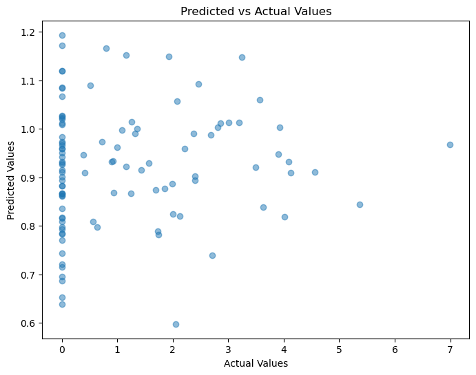

```python
y_pred = improved_model.predict(X_test)


plt.figure(figsize=(8, 6))
plt.scatter(y_test, y_pred, alpha=0.5)
plt.xlabel('Actual Values')
plt.ylabel('Predicted Values')
plt.title('Predicted vs Actual Values')
plt.show()
```

There is a cluster of points where the actual values are 0, but the predicted values are spread around 0.6 to 1.2. This indicates that the model consistently overestimates when the actual value is 0.

For non-zero actual values, the predictions are quite scattered, suggesting that the model struggles to accurately predict these values. There is no clear linear relationship between predicted and actual values, indicating that the model's predictions are not very reliable.

[figure not shown]

```python
history_df = pd.DataFrame(history.history)
plt.figure(figsize=(12, 5))

plt.subplot(1, 2, 1)
plt.plot(history_df['loss'], label='Training Loss')
plt.plot(history_df['val_loss'], label='Validation Loss')
plt.title('Model Training History')
plt.xlabel('Epochs')
plt.ylabel('Loss')
plt.legend()

plt.show()
```

The training loss starts high and decreases rapidly in the first few epochs. After the initial drop, the training loss continues to decrease more slowly, showing some fluctuations indicating that the model is learning and fitting the training data better over time.

The validation loss starts lower than the training loss, which can be seen if early stopping is used or if there's some regularization effect. The validation loss then decreases initially and stabilizes around a certain value with minor fluctuations. This behavior indicates that the model is not overfitting, as the validation loss does not increase significantly over time.

# Improved model 2

Next we can improve the model by increasing the complexity. We will add more layers and neurons to the neural network and see if this improves the model's performance.

We can also evaluate the model using additional metrics like Mean Absolute Error (MAE) and R² Score. These metrics provide more insights into the model's performance.

Mean Absolute Error measures the average magnitude of the errors in a set of predictions, without considering their direction. It's a linear score, which means all individual differences are weighted equally in the average.

R² Score represents the proportion of the variance for the dependent variable that's explained by the independent variables in the model. It provides a measure of how well the observed outcomes are replicated by the model.

```python
from sklearn.metrics import mean_absolute_error, r2_score
```

Improved Model 2 contains an additional hidden layer with 128 neurons, making it a deeper network compared to Improved Model 1. This additional depth allows the model to capture more complex patterns and interactions in the data.

The hidden layers are larger (128 and 64 neurons) compared to Improved Model 1 (64 and 32 neurons). Larger layers can potentially capture more features and interactions, which might improve the model's ability to generalize.

```python
def build_improved_model_2():
    model = Sequential()
    model.add(Input(shape=(X_train.shape[1],)))
    model.add(Dense(128, activation='relu', kernel_regularizer=l2(0.001)))
    model.add(Dropout(0.5))
    model.add(Dense(64, activation='relu', kernel_regularizer=l2(0.001)))
    model.add(Dropout(0.5))
    model.add(Dense(32, activation='relu', kernel_regularizer=l2(0.001)))
    model.add(Dense(1, activation='linear'))
    model.compile(optimizer='adam', loss='mean_squared_error')
    return model
```

The patience parameter for early stopping is set to 10, compared to 5 in the previous model. This allows the model to train for more epochs and potentially converge to a better solution.

```python
improved_model_2 = build_improved_model_2()

early_stopping = EarlyStopping(monitor='val_loss', patience=10, restore_best_weights=True)

history = improved_model_2.fit(X_train, y_train, epochs=100, batch_size=32, validation_split=0.2,
                               callbacks=[early_stopping], verbose=1)
```

```
11/11 ━━━━━━━━━━━━━━━━━━━━ 2s 25ms/step - loss: 3.3003 - val_loss: 1.8926
11/11 ━━━━━━━━━━━━━━━━━━━━ 0s 5ms/step - loss: 2.4917 - val_loss: 1.5889
11/11 ━━━━━━━━━━━━━━━━━━━━ 0s 5ms/step - loss: 2.5119 - val_loss: 1.6289
11/11 ━━━━━━━━━━━━━━━━━━━━ 0s 5ms/step - loss: 2.3879 - val_loss: 1.5738
11/11 ━━━━━━━━━━━━━━━━━━━━ 0s 5ms/step - loss: 2.1973 - val_loss: 1.5732
11/11 ━━━━━━━━━━━━━━━━━━━━ 0s 5ms/step - loss: 2.1120 - val_loss: 1.5654
11/11 ━━━━━━━━━━━━━━━━━━━━ 0s 5ms/step - loss: 2.3467 - val_loss: 1.5597
11/11 ━━━━━━━━━━━━━━━━━━━━ 0s 5ms/step - loss: 2.2847 - val_loss: 1.5545
11/11 ━━━━━━━━━━━━━━━━━━━━ 0s 5ms/step - loss: 2.2450 - val_loss: 1.5544
11/11 ━━━━━━━━━━━━━━━━━━━━ 0s 5ms/step - loss: 2.0515 - val_loss: 1.5552
11/11 ━━━━━━━━━━━━━━━━━━━━ 0s 5ms/step - loss: 2.2339 - val_loss: 1.5447
11/11 ━━━━━━━━━━━━━━━━━━━━ 0s 5ms/step - loss: 2.2402 - val_loss: 1.5451
11/11 ━━━━━━━━━━━━━━━━━━━━ 0s 5ms/step - loss: 2.0148 - val_loss: 1.5506
11/11 ━━━━━━━━━━━━━━━━━━━━ 0s 5ms/step - loss: 2.7080 - val_loss: 1.5565
11/11 ━━━━━━━━━━━━━━━━━━━━ 0s 5ms/step - loss: 2.1916 - val_loss: 1.5798
11/11 ━━━━━━━━━━━━━━━━━━━━ 0s 5ms/step - loss: 2.0892 - val_loss: 1.5486
11/11 ━━━━━━━━━━━━━━━━━━━━ 0s 5ms/step - loss: 2.2757 - val_loss: 1.5428
11/11 ━━━━━━━━━━━━━━━━━━━━ 0s 5ms/step - loss: 2.0286 - val_loss: 1.5452
11/11 ━━━━━━━━━━━━━━━━━━━━ 0s 5ms/step - loss: 2.2924 - val_loss: 1.5444
11/11 ━━━━━━━━━━━━━━━━━━━━ 0s 5ms/step - loss: 2.1638 - val_loss: 1.5395
11/11 ━━━━━━━━━━━━━━━━━━━━ 0s 5ms/step - loss: 2.0552 - val_loss: 1.5467
11/11 ━━━━━━━━━━━━━━━━━━━━ 0s 5ms/step - loss: 2.0727 - val_loss: 1.5396
11/11 ━━━━━━━━━━━━━━━━━━━━ 0s 5ms/step - loss: 2.1978 - val_loss: 1.5425
11/11 ━━━━━━━━━━━━━━━━━━━━ 0s 5ms/step - loss: 2.0735 - val_loss: 1.5433
11/11 ━━━━━━━━━━━━━━━━━━━━ 0s 5ms/step - loss: 2.0821 - val_loss: 1.5358
11/11 ━━━━━━━━━━━━━━━━━━━━ 0s 6ms/step - loss: 2.1773 - val_loss: 1.5341
11/11 ━━━━━━━━━━━━━━━━━━━━ 0s 6ms/step - loss: 2.2018 - val_loss: 1.5346
11/11 ━━━━━━━━━━━━━━━━━━━━ 0s 6ms/step - loss: 2.0690 - val_loss: 1.5333
11/11 ━━━━━━━━━━━━━━━━━━━━ 0s 6ms/step - loss: 2.0545 - val_loss: 1.5353
11/11 ━━━━━━━━━━━━━━━━━━━━ 0s 5ms/step - loss: 2.2361 - val_loss: 1.5304
11/11 ━━━━━━━━━━━━━━━━━━━━ 0s 5ms/step - loss: 2.1470 - val_loss: 1.5341
11/11 ━━━━━━━━━━━━━━━━━━━━ 0s 6ms/step - loss: 1.9909 - val_loss: 1.5325
11/11 ━━━━━━━━━━━━━━━━━━━━ 0s 6ms/step - loss: 2.0613 - val_loss: 1.5302
11/11 ━━━━━━━━━━━━━━━━━━━━ 0s 5ms/step - loss: 2.0703 - val_loss: 1.5295
11/11 ━━━━━━━━━━━━━━━━━━━━ 0s 5ms/step - loss: 2.0248 - val_loss: 1.5333
11/11 ━━━━━━━━━━━━━━━━━━━━ 0s 5ms/step - loss: 2.1182 - val_loss: 1.5292
11/11 ━━━━━━━━━━━━━━━━━━━━ 0s 5ms/step - loss: 1.8609 - val_loss: 1.5232
11/11 ━━━━━━━━━━━━━━━━━━━━ 0s 5ms/step - loss: 2.0966 - val_loss: 1.5258
11/11 ━━━━━━━━━━━━━━━━━━━━ 0s 5ms/step - loss: 1.9208 - val_loss: 1.5277
11/11 ━━━━━━━━━━━━━━━━━━━━ 0s 5ms/step - loss: 1.9114 - val_loss: 1.5223
```

[output cut: 9 more lines]

[output not shown]

```python
mse_test = improved_model_2.evaluate(X_test, y_test)
print(f"Test MSE: {mse_test}")


y_pred = improved_model_2.predict(X_test)

mae = mean_absolute_error(y_test, y_pred)
r2 = r2_score(y_test, y_pred)
print(f"Mean Absolute Error: {mae}")
print(f"R^2 Score: {r2}")
```

```
4/4 ━━━━━━━━━━━━━━━━━━━━ 0s 3ms/step - loss: 2.1082
Test MSE: 2.2897441387176514
4/4 ━━━━━━━━━━━━━━━━━━━━ 0s 1ms/step
Mean Absolute Error: 1.1656468602260215
R^2 Score: -0.001142916220067569
```

The updated model shows a Test MSE of 2.29, Mean Absolute Error (MAE) of 1.17, and R² score of approximately -0.001. This indicates some worsening but still shows that the model struggles to capture the variance in the target variable (area burned).

Mean Absolute Error (MAE) measures the average absolute difference between actual and predicted values. An MAE of 1.17 indicates that on average, the model's predictions are off by approximately 1.17 units.

R² Score measures the proportion of the variance in the dependent variable that is predictable from the independent variables. An R² score of -0.001 is very low, indicating that the model does not explain the variability of the target variable well. A negative R² score suggests that the model performs worse than a simple mean predictor, indicating significant underfitting.

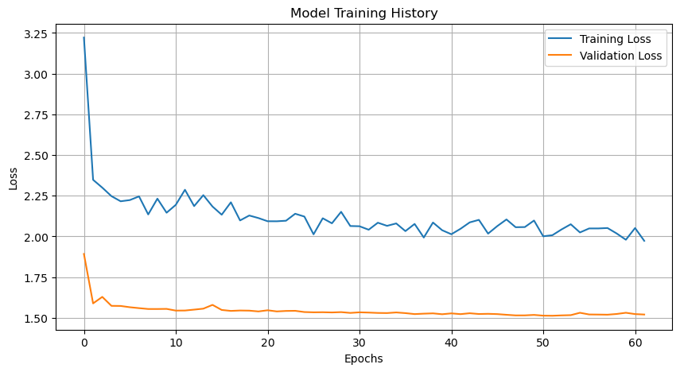

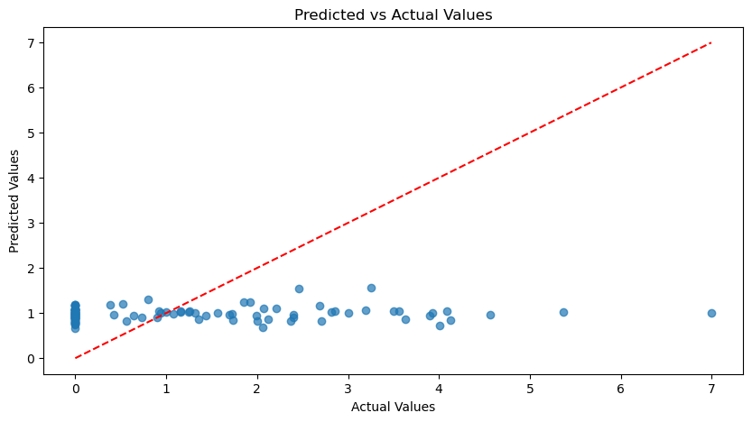

```python
history_df = pd.DataFrame(history.history)
plt.figure(figsize=(10, 5))
plt.plot(history_df['loss'], label='Training Loss')
plt.plot(history_df['val_loss'], label='Validation Loss')
plt.title('Model Training History')
plt.xlabel('Epochs')
plt.ylabel('Loss')
plt.legend()
plt.grid(True)
plt.show()

plt.figure(figsize=(10, 5))
plt.scatter(y_test, y_pred, alpha=0.7)
plt.plot([0, max(y_test)], [0, max(y_test)], 'r--')
plt.xlabel('Actual Values')
plt.ylabel('Predicted Values')
plt.title('Predicted vs Actual Values')
plt.show()
```

The training loss decreases steadily, indicating that the model is learning and fitting to the training data over the epochs. The validation loss remains fairly constant after an initial drop, suggesting that the model is not significantly overfitting to the training data. This is a positive sign as it indicates good generalization to unseen data.

The scatter plot shows a concentration of points around the lower range of actual values. The spread indicates that the model is struggling to predict higher values accurately. Many predicted values are close to 1, regardless of the actual values, which suggests that the model might be underfitting for higher actual values.

The model, while being more complex than simpler models, is still struggling to accurately predict the burnt area, particularly for higher values. This is evident from the scatter plot and the performance metrics.

While Improved Model 2 introduces more complexity with additional layers and neurons, it does not necessarily translate to better performance as indicated by the slightly higher MSE score. This suggests that the additional complexity might have led to overfitting, or the improvements did not generalize well to the test data.

## Wide and Deep Model with Separate Inputs

A Wide and Deep model is a neural network architecture that combines the benefits of wide models, which excel at memorization, and deep models, which are adept at generalization. The wide component directly connects the input to the output, capturing the importance of individual features through linear interactions. The deep component consists of multiple hidden layers that can capture complex, non-linear patterns in the data. This architecture was introduced by Heng-Tze Cheng et al. in 2016.

Wide models are effective at memorizing feature interactions and capturing the direct relationships between features and the target variable. Deep models, with their multiple hidden layers, excel at learning intricate patterns and interactions within the data.

In our approach, we enhanced this concept by implementing a wide and deep model with separate inputs. This design is particularly advantageous when handling diverse feature types, as it allows us to process different feature subsets separately before combining them. The "wide" input manages features that benefit from linear relationships, while the "deep" input processes features requiring more complex, abstract representations.

This approach aims to capture both memorization and generalization effectively, leveraging wide models for feature crosses and deep models for high-level abstractions. This architecture is well-suited for our forest fire prediction task, as it can simultaneously learn from straightforward linear patterns and complex interactions within the data. By experimenting with this model, we aimed to balance bias and variance, ultimately improving the model's performance on unseen data.

First data is prepared, scaled and split.

The training, validation, and test sets are then split into "wide" and "deep" parts. The first 5 columns are taken as the "wide" part, and the remaining columns are taken as the "deep" part. This allows the model to separately process simpler, linear relationships (wide) and more complex, non-linear relationships (deep).

```python
from tensorflow.keras import layers, models

X = df.drop('area', axis=1).values
y = df['area'].values

scaler = MinMaxScaler()
X_scaled = scaler.fit_transform(X)

X_train_full, X_test, y_train_full, y_test = train_test_split(X_scaled, y, test_size=0.2, random_state=42)
X_train, X_valid, y_train, y_valid = train_test_split(X_train_full, y_train_full, test_size=0.2, random_state=42)

X_train_wide, X_train_deep = X_train[:, :5], X_train[:, 5:]
X_valid_wide, X_valid_deep = X_valid[:, :5], X_valid[:, 5:]
X_test_wide, X_test_deep = X_test[:, :5], X_test[:, 5:]
```

The function build_wide_and_deep_model constructs a neural network that processes wide and deep inputs separately, concatenates their results, and outputs a single prediction. The model is compiled with MSE loss and SGD optimizer, and the constructed model instance is returned.

SGD was used this time instead of the Adam optimizer owing to it's simplicity and interpretability. Moreover, SGD’s slower convergence can be beneficial in preventing overfitting.

```python
def build_wide_and_deep_model():
    input_wide = layers.Input(shape=[X_train_wide.shape[1]], name="wide_input")
    input_deep = layers.Input(shape=[X_train_deep.shape[1]], name="deep_input")

    hidden1 = layers.Dense(30, activation="relu")(input_deep)
    hidden2 = layers.Dense(30, activation="relu")(hidden1)

    concat = layers.Concatenate()([input_wide, hidden2])
    output = layers.Dense(1)(concat)

    model = models.Model(inputs=[input_wide, input_deep], outputs=[output])
    model.compile(loss="mse", optimizer=tf.keras.optimizers.SGD(learning_rate=1e-3))

    return model

model = build_wide_and_deep_model()
```

```python
history = model.fit([X_train_wide, X_train_deep], y_train, epochs=100, validation_data=([X_valid_wide, X_valid_deep], y_valid), verbose=1)
```

```
11/11 ━━━━━━━━━━━━━━━━━━━━ 1s 52ms/step - loss: 4.0381 - val_loss: 2.2746
11/11 ━━━━━━━━━━━━━━━━━━━━ 0s 15ms/step - loss: 3.8575 - val_loss: 2.0591
11/11 ━━━━━━━━━━━━━━━━━━━━ 0s 17ms/step - loss: 3.0062 - val_loss: 1.8846
11/11 ━━━━━━━━━━━━━━━━━━━━ 0s 16ms/step - loss: 3.2814 - val_loss: 1.7506
11/11 ━━━━━━━━━━━━━━━━━━━━ 0s 9ms/step - loss: 2.5720 - val_loss: 1.6431
11/11 ━━━━━━━━━━━━━━━━━━━━ 0s 23ms/step - loss: 2.8308 - val_loss: 1.5615
11/11 ━━━━━━━━━━━━━━━━━━━━ 0s 5ms/step - loss: 2.6135 - val_loss: 1.4962
11/11 ━━━━━━━━━━━━━━━━━━━━ 0s 14ms/step - loss: 2.2711 - val_loss: 1.4487
11/11 ━━━━━━━━━━━━━━━━━━━━ 0s 5ms/step - loss: 2.4508 - val_loss: 1.4117
11/11 ━━━━━━━━━━━━━━━━━━━━ 0s 5ms/step - loss: 2.2880 - val_loss: 1.3820
11/11 ━━━━━━━━━━━━━━━━━━━━ 0s 5ms/step - loss: 2.1658 - val_loss: 1.3624
11/11 ━━━━━━━━━━━━━━━━━━━━ 0s 4ms/step - loss: 1.9429 - val_loss: 1.3465
11/11 ━━━━━━━━━━━━━━━━━━━━ 0s 5ms/step - loss: 2.0288 - val_loss: 1.3368
11/11 ━━━━━━━━━━━━━━━━━━━━ 0s 16ms/step - loss: 2.2169 - val_loss: 1.3317
11/11 ━━━━━━━━━━━━━━━━━━━━ 0s 5ms/step - loss: 2.5816 - val_loss: 1.3300
11/11 ━━━━━━━━━━━━━━━━━━━━ 0s 6ms/step - loss: 2.0317 - val_loss: 1.3307
11/11 ━━━━━━━━━━━━━━━━━━━━ 0s 4ms/step - loss: 2.3110 - val_loss: 1.3325
11/11 ━━━━━━━━━━━━━━━━━━━━ 0s 5ms/step - loss: 2.2449 - val_loss: 1.3349
11/11 ━━━━━━━━━━━━━━━━━━━━ 0s 5ms/step - loss: 2.1146 - val_loss: 1.3391
11/11 ━━━━━━━━━━━━━━━━━━━━ 0s 5ms/step - loss: 1.6459 - val_loss: 1.3439
11/11 ━━━━━━━━━━━━━━━━━━━━ 0s 7ms/step - loss: 2.2258 - val_loss: 1.3499
11/11 ━━━━━━━━━━━━━━━━━━━━ 0s 4ms/step - loss: 1.8947 - val_loss: 1.3556
11/11 ━━━━━━━━━━━━━━━━━━━━ 0s 5ms/step - loss: 2.1049 - val_loss: 1.3601
11/11 ━━━━━━━━━━━━━━━━━━━━ 0s 5ms/step - loss: 2.1580 - val_loss: 1.3622
11/11 ━━━━━━━━━━━━━━━━━━━━ 0s 5ms/step - loss: 2.2416 - val_loss: 1.3669
11/11 ━━━━━━━━━━━━━━━━━━━━ 0s 5ms/step - loss: 2.0539 - val_loss: 1.3725
11/11 ━━━━━━━━━━━━━━━━━━━━ 0s 5ms/step - loss: 2.1606 - val_loss: 1.3753
11/11 ━━━━━━━━━━━━━━━━━━━━ 0s 5ms/step - loss: 1.8888 - val_loss: 1.3817
11/11 ━━━━━━━━━━━━━━━━━━━━ 0s 5ms/step - loss: 2.0205 - val_loss: 1.3858
11/11 ━━━━━━━━━━━━━━━━━━━━ 0s 4ms/step - loss: 1.8585 - val_loss: 1.3910
11/11 ━━━━━━━━━━━━━━━━━━━━ 0s 5ms/step - loss: 2.1222 - val_loss: 1.3937
11/11 ━━━━━━━━━━━━━━━━━━━━ 0s 5ms/step - loss: 2.1296 - val_loss: 1.3981
11/11 ━━━━━━━━━━━━━━━━━━━━ 0s 5ms/step - loss: 1.9384 - val_loss: 1.4013
11/11 ━━━━━━━━━━━━━━━━━━━━ 0s 5ms/step - loss: 1.9315 - val_loss: 1.4048
11/11 ━━━━━━━━━━━━━━━━━━━━ 0s 5ms/step - loss: 2.0387 - val_loss: 1.4030
11/11 ━━━━━━━━━━━━━━━━━━━━ 0s 6ms/step - loss: 2.1050 - val_loss: 1.4006
11/11 ━━━━━━━━━━━━━━━━━━━━ 0s 6ms/step - loss: 2.0560 - val_loss: 1.3999
11/11 ━━━━━━━━━━━━━━━━━━━━ 0s 7ms/step - loss: 1.8545 - val_loss: 1.3992
11/11 ━━━━━━━━━━━━━━━━━━━━ 0s 5ms/step - loss: 1.8614 - val_loss: 1.4006
11/11 ━━━━━━━━━━━━━━━━━━━━ 0s 5ms/step - loss: 1.9259 - val_loss: 1.4030
```

[output cut: 45 more lines]

```
11/11 ━━━━━━━━━━━━━━━━━━━━ 0s 6ms/step - loss: 1.9509 - val_loss: 1.4136
11/11 ━━━━━━━━━━━━━━━━━━━━ 0s 5ms/step - loss: 1.9271 - val_loss: 1.4175
11/11 ━━━━━━━━━━━━━━━━━━━━ 0s 6ms/step - loss: 1.9800 - val_loss: 1.4154
11/11 ━━━━━━━━━━━━━━━━━━━━ 0s 5ms/step - loss: 1.9187 - val_loss: 1.4155
11/11 ━━━━━━━━━━━━━━━━━━━━ 0s 6ms/step - loss: 1.7606 - val_loss: 1.4170
11/11 ━━━━━━━━━━━━━━━━━━━━ 0s 5ms/step - loss: 1.9609 - val_loss: 1.4156
11/11 ━━━━━━━━━━━━━━━━━━━━ 0s 5ms/step - loss: 2.0327 - val_loss: 1.4149
11/11 ━━━━━━━━━━━━━━━━━━━━ 0s 5ms/step - loss: 1.9970 - val_loss: 1.4126
11/11 ━━━━━━━━━━━━━━━━━━━━ 0s 4ms/step - loss: 1.9272 - val_loss: 1.4109
11/11 ━━━━━━━━━━━━━━━━━━━━ 0s 5ms/step - loss: 2.2921 - val_loss: 1.4057
11/11 ━━━━━━━━━━━━━━━━━━━━ 0s 5ms/step - loss: 1.9299 - val_loss: 1.4034
11/11 ━━━━━━━━━━━━━━━━━━━━ 0s 6ms/step - loss: 2.0972 - val_loss: 1.4028
11/11 ━━━━━━━━━━━━━━━━━━━━ 0s 5ms/step - loss: 1.9252 - val_loss: 1.4059
11/11 ━━━━━━━━━━━━━━━━━━━━ 0s 5ms/step - loss: 1.9793 - val_loss: 1.4093
11/11 ━━━━━━━━━━━━━━━━━━━━ 0s 5ms/step - loss: 2.1723 - val_loss: 1.4116
```

```python
y_pred = model.predict([X_test_wide, X_test_deep])

mse_test = model.evaluate([X_test_wide, X_test_deep], y_test)
print(f"Test MSE: {mse_test}")

mae = mean_absolute_error(y_test, y_pred)
print(f"MAE: {mae}")

r2 = r2_score(y_test, y_pred)
print(f"R²: {r2}")
```

```
4/4 ━━━━━━━━━━━━━━━━━━━━ 0s 2ms/step
4/4 ━━━━━━━━━━━━━━━━━━━━ 0s 1ms/step - loss: 2.0072
Test MSE: 2.1595146656036377
MAE: 1.2062638631608364
R²: 0.017447337168725152
```

The Test MSE is 2.1595 which is an improvement compared with previous MSE scores. The MAE of 1.2063 means that, on average, the model's predictions are off by about 1.2063 units from the actual values.

An R² score of 1 indicates perfect predictions, while an R² of 0 indicates that the model does no better than simply predicting the mean of the target variable. An R² of 0.0174 is quite low, suggesting that the model is only slightly better than a simple mean predictor.

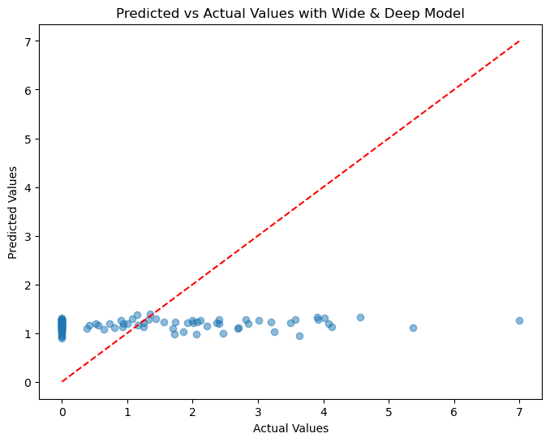

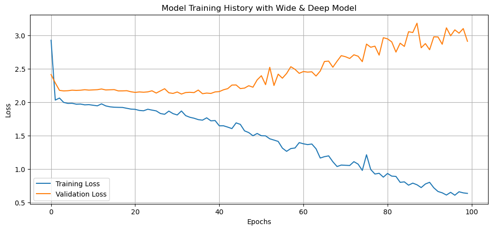

```python
plt.figure(figsize=(8, 6))
plt.scatter(y_test, y_pred, alpha=0.5)
plt.plot([0, max(y_test)], [0, max(y_test)], color='red', linestyle='--')
plt.xlabel('Actual Values')
plt.ylabel('Predicted Values')
plt.title('Predicted vs Actual Values with Wide & Deep Model')
plt.show()


history_df = pd.DataFrame(history.history)
plt.figure(figsize=(12, 5))
plt.plot(history_df['loss'], label='Training Loss')
plt.plot(history_df['val_loss'], label='Validation Loss')
plt.title('Model Training History with Wide & Deep Model')
plt.xlabel('Epochs')
plt.ylabel('Loss')
plt.legend()
plt.grid(True)
plt.show()
```

The test MSE of 2.1595146656036377 is an improvement over previous models but still suggests that the model can be improved further.

The scatter plot suggests that the model still has a lot of room for improvement. Most predicted values are clustered around the lower end, indicating that the model struggles to predict higher values accurately.

The training loss starts high and decreases rapidly in the initial epochs. After the initial sharp decrease, the training loss continues to decrease more gradually and shows a steady decline with some fluctuations. This indicates that the model is learning from the training data and improving its performance over time.

The validation loss decreases initially but then stabilizes and starts to increase with noticeable fluctuations after the initial epochs. The increasing trend in validation loss, especially after around epoch 40, suggests that the model is overfitting to the training data.

# Residual networks

Residual networks (ResNets) are a powerful type of neural network architecture designed to address the problem of vanishing gradients in deep networks by allowing gradients to flow through the network directly.

The residual connections help the network learn identity mappings, making it easier to optimize deeper layers and improve overall performance.

```python
X = df.drop('area', axis=1)
y = df['area']


scaler = MinMaxScaler()
X_scaled = scaler.fit_transform(X)


X_train, X_test, y_train, y_test = train_test_split(X_scaled, y, test_size=0.2, random_state=42)
X_train, X_valid, y_train, y_valid = train_test_split(X_train, y_train, test_size=0.2, random_state=42)
```

The model is built with three hidden layers and a single neuron with a linear activation function to predict the target variable.

The residual model is inherently more complex and deeper due to the residual connections. The adaptive nature of Adam helps in efficiently training deeper models, making it a more suitable choice for the residual network over SGD.

```python
def build_residual_network():
    input_layer = Input(shape=(X_train.shape[1],))


    hidden1 = Dense(64, activation='relu')(input_layer)


    hidden2 = Dense(64, activation='relu')(hidden1)
    hidden3 = Dense(64, activation=None)(hidden2)
    residual_output = Add()([hidden1, hidden3])
    residual_output = Activation('relu')(residual_output)


    output_layer = Dense(1, activation='linear')(residual_output)

    model = Model(inputs=[input_layer], outputs=[output_layer])
    model.compile(optimizer=Adam(learning_rate=0.001), loss='mean_squared_error')
    return model

model = build_residual_network()
```

The EarlyStopping callback is used to monitor the validation loss. If the validation loss does not improve for 10 consecutive epochs, training is stopped early, and the best model weights are restored.

```python
early_stopping = tf.keras.callbacks.EarlyStopping(monitor='val_loss', patience=10, restore_best_weights=True)

history = model.fit(X_train, y_train, epochs=100, batch_size=32, validation_data=(X_valid, y_valid),
                    callbacks=[early_stopping], verbose=1)
```

```
11/11 ━━━━━━━━━━━━━━━━━━━━ 3s 70ms/step - loss: 4.8765 - val_loss: 1.4190
11/11 ━━━━━━━━━━━━━━━━━━━━ 0s 16ms/step - loss: 2.1178 - val_loss: 1.5974
11/11 ━━━━━━━━━━━━━━━━━━━━ 0s 6ms/step - loss: 1.9120 - val_loss: 1.6010
11/11 ━━━━━━━━━━━━━━━━━━━━ 0s 7ms/step - loss: 1.9059 - val_loss: 1.4205
11/11 ━━━━━━━━━━━━━━━━━━━━ 0s 7ms/step - loss: 2.0254 - val_loss: 1.4196
11/11 ━━━━━━━━━━━━━━━━━━━━ 0s 4ms/step - loss: 1.8229 - val_loss: 1.4492
11/11 ━━━━━━━━━━━━━━━━━━━━ 0s 5ms/step - loss: 1.9212 - val_loss: 1.4596
11/11 ━━━━━━━━━━━━━━━━━━━━ 0s 4ms/step - loss: 1.7993 - val_loss: 1.4148
11/11 ━━━━━━━━━━━━━━━━━━━━ 0s 7ms/step - loss: 1.9146 - val_loss: 1.4506
11/11 ━━━━━━━━━━━━━━━━━━━━ 0s 5ms/step - loss: 1.9986 - val_loss: 1.4752
11/11 ━━━━━━━━━━━━━━━━━━━━ 0s 7ms/step - loss: 1.8950 - val_loss: 1.3954
11/11 ━━━━━━━━━━━━━━━━━━━━ 0s 5ms/step - loss: 2.0954 - val_loss: 1.4587
11/11 ━━━━━━━━━━━━━━━━━━━━ 0s 7ms/step - loss: 2.0852 - val_loss: 1.4082
11/11 ━━━━━━━━━━━━━━━━━━━━ 0s 5ms/step - loss: 2.0753 - val_loss: 1.4425
11/11 ━━━━━━━━━━━━━━━━━━━━ 0s 5ms/step - loss: 1.8801 - val_loss: 1.3715
11/11 ━━━━━━━━━━━━━━━━━━━━ 0s 6ms/step - loss: 1.8412 - val_loss: 1.4200
11/11 ━━━━━━━━━━━━━━━━━━━━ 0s 6ms/step - loss: 1.8817 - val_loss: 1.4043
11/11 ━━━━━━━━━━━━━━━━━━━━ 0s 5ms/step - loss: 1.8416 - val_loss: 1.4029
11/11 ━━━━━━━━━━━━━━━━━━━━ 0s 5ms/step - loss: 1.8310 - val_loss: 1.4043
11/11 ━━━━━━━━━━━━━━━━━━━━ 0s 5ms/step - loss: 1.7918 - val_loss: 1.3994
11/11 ━━━━━━━━━━━━━━━━━━━━ 0s 5ms/step - loss: 2.0547 - val_loss: 1.3662
11/11 ━━━━━━━━━━━━━━━━━━━━ 0s 5ms/step - loss: 1.7045 - val_loss: 1.3682
11/11 ━━━━━━━━━━━━━━━━━━━━ 0s 6ms/step - loss: 1.7770 - val_loss: 1.4603
11/11 ━━━━━━━━━━━━━━━━━━━━ 0s 8ms/step - loss: 2.1262 - val_loss: 1.3582
11/11 ━━━━━━━━━━━━━━━━━━━━ 0s 5ms/step - loss: 1.8467 - val_loss: 1.3946
11/11 ━━━━━━━━━━━━━━━━━━━━ 0s 6ms/step - loss: 1.9243 - val_loss: 1.3643
11/11 ━━━━━━━━━━━━━━━━━━━━ 0s 5ms/step - loss: 1.8035 - val_loss: 1.3699
11/11 ━━━━━━━━━━━━━━━━━━━━ 0s 5ms/step - loss: 1.8605 - val_loss: 1.3781
11/11 ━━━━━━━━━━━━━━━━━━━━ 0s 5ms/step - loss: 1.9285 - val_loss: 1.3667
11/11 ━━━━━━━━━━━━━━━━━━━━ 0s 4ms/step - loss: 1.8946 - val_loss: 1.3582
11/11 ━━━━━━━━━━━━━━━━━━━━ 0s 5ms/step - loss: 1.9438 - val_loss: 1.4125
11/11 ━━━━━━━━━━━━━━━━━━━━ 0s 5ms/step - loss: 1.9033 - val_loss: 1.3208
11/11 ━━━━━━━━━━━━━━━━━━━━ 0s 5ms/step - loss: 1.9699 - val_loss: 1.4383
11/11 ━━━━━━━━━━━━━━━━━━━━ 0s 5ms/step - loss: 1.5488 - val_loss: 1.4020
11/11 ━━━━━━━━━━━━━━━━━━━━ 0s 5ms/step - loss: 1.7485 - val_loss: 1.3997
11/11 ━━━━━━━━━━━━━━━━━━━━ 0s 8ms/step - loss: 1.6345 - val_loss: 1.3855
11/11 ━━━━━━━━━━━━━━━━━━━━ 0s 5ms/step - loss: 1.8537 - val_loss: 1.3847
11/11 ━━━━━━━━━━━━━━━━━━━━ 0s 5ms/step - loss: 1.8360 - val_loss: 1.4191
11/11 ━━━━━━━━━━━━━━━━━━━━ 0s 5ms/step - loss: 1.6569 - val_loss: 1.4426
11/11 ━━━━━━━━━━━━━━━━━━━━ 0s 5ms/step - loss: 1.7046 - val_loss: 1.4390
11/11 ━━━━━━━━━━━━━━━━━━━━ 0s 5ms/step - loss: 1.7520 - val_loss: 1.4396
11/11 ━━━━━━━━━━━━━━━━━━━━ 0s 5ms/step - loss: 1.6559 - val_loss: 1.4839
```

```python
mse_test = model.evaluate(X_test, y_test, verbose=1)
print(f"Test MSE: {mse_test}")


y_pred = model.predict(X_test)


mae = mean_absolute_error(y_test, y_pred)
r2 = r2_score(y_test, y_pred)
print(f"Test MAE: {mae}")
print(f"Test R²: {r2}")
```

```
4/4 ━━━━━━━━━━━━━━━━━━━━ 0s 44ms/step - loss: 1.9333
Test MSE: 2.1158199310302734
4/4 ━━━━━━━━━━━━━━━━━━━━ 0s 19ms/step
Test MAE: 1.143120179190695
Test R²: 0.037327918898268364
```

The residual network model shows promising results compared to previous models. The model incorporates a residual block, which helps mitigate issues related to vanishing gradients and allows deeper network training. The residual block adds the input directly to the output of the block before applying the activation function. This helps the network learn identity mappings, which are easier to optimize.

The mean squared error (MSE) of 2.1158 is an improvement compared to previous models, suggesting better predictive performance. The mean absolute error (MAE) of 1.1431 is lower than many previous models, indicating that the model's predictions are closer to the actual values on average. The R² score of 0.0373, while not high, is positive, indicating that the model explains some of the variance in the target variable.

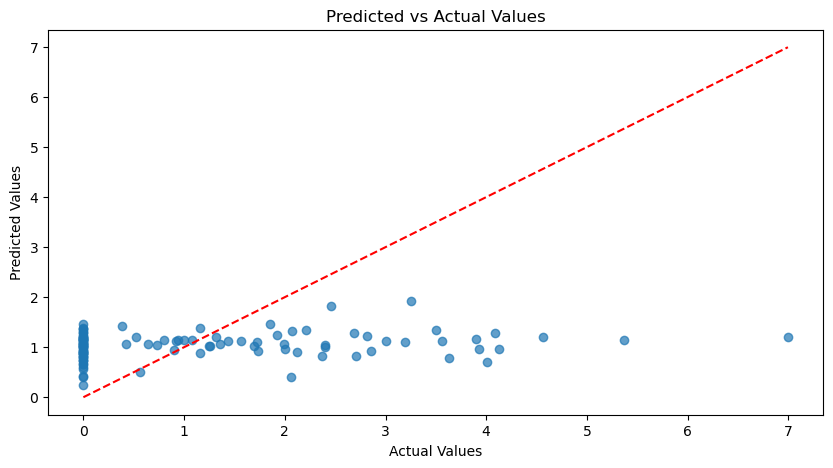

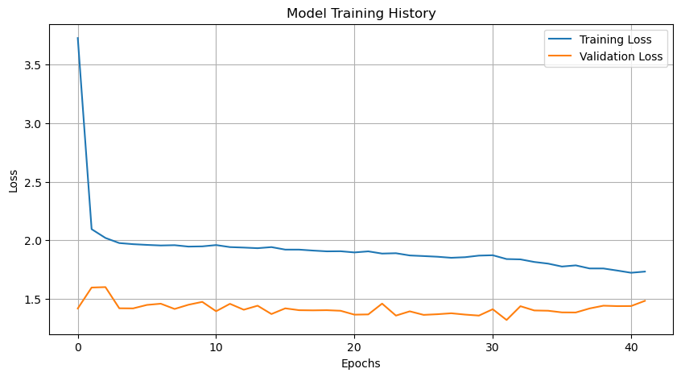

```python
plt.figure(figsize=(10, 5))
plt.scatter(y_test, y_pred, alpha=0.7)
plt.plot([0, max(y_test)], [0, max(y_test)], 'r--')
plt.xlabel('Actual Values')
plt.ylabel('Predicted Values')
plt.title('Predicted vs Actual Values')
plt.show()

history_df = pd.DataFrame(history.history)
plt.figure(figsize=(10, 5))
plt.plot(history_df['loss'], label='Training Loss')
plt.plot(history_df['val_loss'], label='Validation Loss')
plt.title('Model Training History')
plt.xlabel('Epochs')
plt.ylabel('Loss')
plt.legend()
plt.grid(True)
plt.show()
```

The scatter plot of predicted vs. actual values indicates that the model's predictions are fairly consistent but have a tendency to predict values close to 1.0 regardless of the actual value. There is a significant concentration of points around the lower values, with less accuracy as the actual values increase. The model is not capturing the variability in the data well, especially for higher values. This suggests that while the model performs reasonably for lower values, it struggles with higher ones, indicating a potential underfitting issue.

The model is learning well initially but shows signs of slight overfitting as the training progresses. The validation loss diverging from the training loss suggests the model's performance on unseen data is not improving as much as on the training data.

The residual network model has demonstrated improved performance metrics compared to the baseline and many other improved models.

# Modified residual network model with increased complexity and L1/L2 regularization.

Next we can try enhancing the basic residual network model by incorporating several key improvements aimed at boosting performance and preventing overfitting.

```python
from tensorflow.keras.regularizers import l1_l2
```

Firstly, L1 and L2 regularization is introduced in each dense layer to penalize large weights and promote model generalization.

Secondly, the complexity of the network is increased by expanding the number of neurons in the hidden layers to 128, allowing the model to capture more intricate patterns in the data. The residual connections are maintained to mitigate the vanishing gradient problem, ensuring that gradients can flow through the network more effectively.

Finally, the use of the Adam optimizer with an adaptive learning rate facilitates more efficient training, while an early stopping mechanism is employed to halt training when the validation loss ceases to improve, thus preserving the best model weights and preventing overfitting. These enhancements collectively aim to create a more robust and accurate predictive model.

```python
def build_residual_network():
    input_layer = Input(shape=(X_train.shape[1],))

    hidden1 = Dense(128, activation='relu', kernel_regularizer=l1_l2(l1=0.001, l2=0.001))(input_layer)
    hidden2 = Dense(128, activation='relu', kernel_regularizer=l1_l2(l1=0.001, l2=0.001))(hidden1)
    hidden3 = Dense(128, activation=None, kernel_regularizer=l1_l2(l1=0.001, l2=0.001))(hidden2)
    residual_output = Add()([hidden1, hidden3])
    residual_output = Activation('relu')(residual_output)

    output_layer = Dense(1, activation='linear')(residual_output)

    model = Model(inputs=[input_layer], outputs=[output_layer])
    model.compile(optimizer=Adam(learning_rate=0.001), loss='mean_squared_error')
    return model

model = build_residual_network()


early_stopping = EarlyStopping(monitor='val_loss', patience=10, restore_best_weights=True)


history = model.fit(X_train, y_train, epochs=100, batch_size=32, validation_data=(X_valid, y_valid),
                    callbacks=[early_stopping], verbose=1)
```

```
11/11 ━━━━━━━━━━━━━━━━━━━━ 3s 137ms/step - loss: 5.7434 - val_loss: 4.5009
11/11 ━━━━━━━━━━━━━━━━━━━━ 1s 52ms/step - loss: 4.7567 - val_loss: 3.8472
11/11 ━━━━━━━━━━━━━━━━━━━━ 0s 40ms/step - loss: 4.6215 - val_loss: 3.6706
11/11 ━━━━━━━━━━━━━━━━━━━━ 0s 14ms/step - loss: 3.9106 - val_loss: 3.4970
11/11 ━━━━━━━━━━━━━━━━━━━━ 0s 5ms/step - loss: 3.9772 - val_loss: 3.3257
11/11 ━━━━━━━━━━━━━━━━━━━━ 1s 54ms/step - loss: 3.5821 - val_loss: 3.1080
11/11 ━━━━━━━━━━━━━━━━━━━━ 0s 6ms/step - loss: 3.6650 - val_loss: 2.9567
11/11 ━━━━━━━━━━━━━━━━━━━━ 0s 6ms/step - loss: 3.5271 - val_loss: 2.8507
11/11 ━━━━━━━━━━━━━━━━━━━━ 0s 6ms/step - loss: 3.3252 - val_loss: 2.6148
11/11 ━━━━━━━━━━━━━━━━━━━━ 0s 5ms/step - loss: 2.9807 - val_loss: 2.6172
11/11 ━━━━━━━━━━━━━━━━━━━━ 0s 16ms/step - loss: 3.2275 - val_loss: 2.4391
11/11 ━━━━━━━━━━━━━━━━━━━━ 0s 7ms/step - loss: 2.7803 - val_loss: 2.3256
11/11 ━━━━━━━━━━━━━━━━━━━━ 0s 12ms/step - loss: 2.6991 - val_loss: 2.3770
11/11 ━━━━━━━━━━━━━━━━━━━━ 0s 39ms/step - loss: 2.9237 - val_loss: 2.2138
11/11 ━━━━━━━━━━━━━━━━━━━━ 0s 38ms/step - loss: 2.7511 - val_loss: 2.1642
11/11 ━━━━━━━━━━━━━━━━━━━━ 0s 5ms/step - loss: 2.5773 - val_loss: 2.3048
11/11 ━━━━━━━━━━━━━━━━━━━━ 0s 5ms/step - loss: 2.6805 - val_loss: 2.0701
11/11 ━━━━━━━━━━━━━━━━━━━━ 0s 5ms/step - loss: 2.5713 - val_loss: 2.2455
11/11 ━━━━━━━━━━━━━━━━━━━━ 0s 5ms/step - loss: 2.6930 - val_loss: 2.0550
11/11 ━━━━━━━━━━━━━━━━━━━━ 0s 5ms/step - loss: 2.4688 - val_loss: 2.0887
11/11 ━━━━━━━━━━━━━━━━━━━━ 0s 5ms/step - loss: 2.6646 - val_loss: 2.0036
11/11 ━━━━━━━━━━━━━━━━━━━━ 0s 5ms/step - loss: 2.3653 - val_loss: 2.0581
11/11 ━━━━━━━━━━━━━━━━━━━━ 0s 5ms/step - loss: 2.6362 - val_loss: 2.0567
11/11 ━━━━━━━━━━━━━━━━━━━━ 0s 5ms/step - loss: 2.4175 - val_loss: 1.9499
11/11 ━━━━━━━━━━━━━━━━━━━━ 0s 5ms/step - loss: 2.6201 - val_loss: 1.9894
11/11 ━━━━━━━━━━━━━━━━━━━━ 0s 5ms/step - loss: 2.4024 - val_loss: 1.8999
11/11 ━━━━━━━━━━━━━━━━━━━━ 0s 5ms/step - loss: 2.6000 - val_loss: 1.9502
11/11 ━━━━━━━━━━━━━━━━━━━━ 0s 5ms/step - loss: 2.4619 - val_loss: 1.8321
11/11 ━━━━━━━━━━━━━━━━━━━━ 0s 5ms/step - loss: 2.5435 - val_loss: 1.9312
11/11 ━━━━━━━━━━━━━━━━━━━━ 0s 5ms/step - loss: 2.3663 - val_loss: 1.8260
11/11 ━━━━━━━━━━━━━━━━━━━━ 0s 5ms/step - loss: 2.3250 - val_loss: 1.9396
11/11 ━━━━━━━━━━━━━━━━━━━━ 0s 12ms/step - loss: 2.2459 - val_loss: 1.7932
11/11 ━━━━━━━━━━━━━━━━━━━━ 0s 5ms/step - loss: 2.3066 - val_loss: 1.8896
11/11 ━━━━━━━━━━━━━━━━━━━━ 0s 10ms/step - loss: 2.4052 - val_loss: 1.7920
11/11 ━━━━━━━━━━━━━━━━━━━━ 0s 5ms/step - loss: 2.2922 - val_loss: 1.7778
11/11 ━━━━━━━━━━━━━━━━━━━━ 0s 5ms/step - loss: 2.2772 - val_loss: 1.8512
11/11 ━━━━━━━━━━━━━━━━━━━━ 0s 5ms/step - loss: 2.2875 - val_loss: 1.7631
11/11 ━━━━━━━━━━━━━━━━━━━━ 0s 5ms/step - loss: 2.1351 - val_loss: 1.7603
11/11 ━━━━━━━━━━━━━━━━━━━━ 0s 5ms/step - loss: 2.2353 - val_loss: 1.7349
11/11 ━━━━━━━━━━━━━━━━━━━━ 0s 5ms/step - loss: 2.2004 - val_loss: 1.7763
```

[output cut: 21 more lines]

```
11/11 ━━━━━━━━━━━━━━━━━━━━ 0s 5ms/step - loss: 2.1870 - val_loss: 1.5915
11/11 ━━━━━━━━━━━━━━━━━━━━ 0s 5ms/step - loss: 2.0573 - val_loss: 1.6202
11/11 ━━━━━━━━━━━━━━━━━━━━ 0s 5ms/step - loss: 2.0123 - val_loss: 1.6293
11/11 ━━━━━━━━━━━━━━━━━━━━ 0s 4ms/step - loss: 2.4596 - val_loss: 1.6067
11/11 ━━━━━━━━━━━━━━━━━━━━ 0s 5ms/step - loss: 2.0579 - val_loss: 1.5255
11/11 ━━━━━━━━━━━━━━━━━━━━ 0s 5ms/step - loss: 2.0527 - val_loss: 1.7153
11/11 ━━━━━━━━━━━━━━━━━━━━ 0s 5ms/step - loss: 1.9867 - val_loss: 1.5629
11/11 ━━━━━━━━━━━━━━━━━━━━ 0s 5ms/step - loss: 2.0327 - val_loss: 1.5737
11/11 ━━━━━━━━━━━━━━━━━━━━ 0s 5ms/step - loss: 2.1608 - val_loss: 1.6131
11/11 ━━━━━━━━━━━━━━━━━━━━ 0s 5ms/step - loss: 2.2208 - val_loss: 1.5836
11/11 ━━━━━━━━━━━━━━━━━━━━ 0s 5ms/step - loss: 2.1248 - val_loss: 1.5653
11/11 ━━━━━━━━━━━━━━━━━━━━ 0s 5ms/step - loss: 2.0055 - val_loss: 1.5984
11/11 ━━━━━━━━━━━━━━━━━━━━ 0s 5ms/step - loss: 2.1907 - val_loss: 1.5785
11/11 ━━━━━━━━━━━━━━━━━━━━ 0s 4ms/step - loss: 2.3025 - val_loss: 1.5560
11/11 ━━━━━━━━━━━━━━━━━━━━ 0s 5ms/step - loss: 2.1524 - val_loss: 1.5393
```

```python
mse_test = model.evaluate(X_test, y_test, verbose=1)
print(f"Test MSE: {mse_test}")

y_pred = model.predict(X_test)

mae = mean_absolute_error(y_test, y_pred)
print(f"Test MAE: {mae}")

r2 = r2_score(y_test, y_pred)
print(f"Test R²: {r2}")
```

```
4/4 ━━━━━━━━━━━━━━━━━━━━ 0s 14ms/step - loss: 2.1981
Test MSE: 2.375818967819214
4/4 ━━━━━━━━━━━━━━━━━━━━ 0s 46ms/step
Test MAE: 1.1527189824376614
Test R²: 0.020268713718710196
```

The latest residual network model, which incorporated increased complexity and regularization techniques, resulted in a Test MSE of 2.3758, a Test MAE of 1.1527, and a Test R² score of 0.0203. This indicates a slight increase in MSE compared to the previous model, which had a Test MSE of 2.1158. The increase in MSE suggests that the additional complexity and regularization might have led to overfitting or the model's inability to generalize as effectively as before.

While the Test MAE remained relatively stable, indicating consistent average error magnitude, the Test R² score shows a marginal positive value, reflecting minimal explanatory power of the model for the variability in the target variable.

Including a residuals distribution plot provides a deeper insight into the model's performance by showing the spread and central tendency of prediction errors.

This plot is particularly useful for diagnosing bias (systematic errors) and variance (spread of errors). By examining the distribution of residuals, we can understand if the model consistently overpredicts or underpredicts and identify any patterns in the errors.

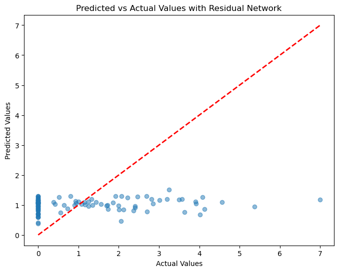

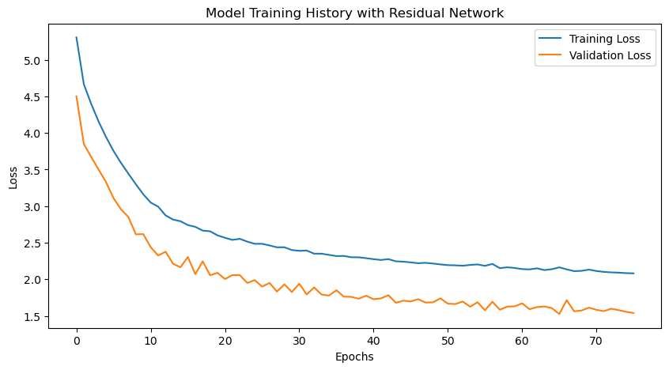

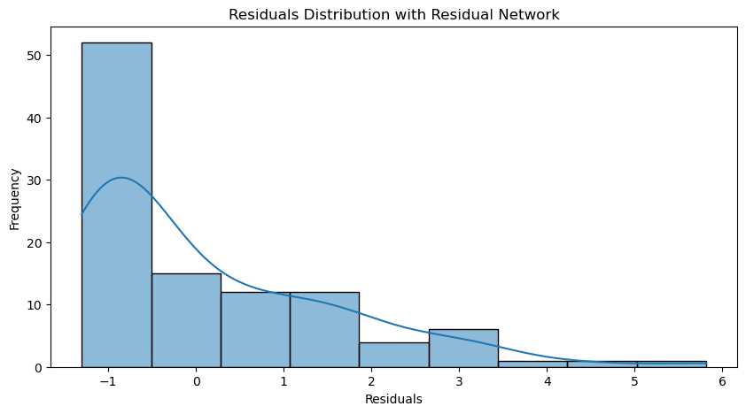

```python
plt.figure(figsize=(8, 6))
plt.scatter(y_test, y_pred, alpha=0.5)
plt.plot([y_test.min(), y_test.max()], [y_test.min(), y_test.max()], 'r--', lw=2)
plt.xlabel('Actual Values')
plt.ylabel('Predicted Values')
plt.title('Predicted vs Actual Values with Residual Network')
plt.show()


plt.figure(figsize=(10, 5))
plt.plot(history.history['loss'], label='Training Loss')
plt.plot(history.history['val_loss'], label='Validation Loss')
plt.title('Model Training History with Residual Network')
plt.xlabel('Epochs')
plt.ylabel('Loss')
plt.legend()
plt.show()


residuals = y_test - y_pred.flatten()
plt.figure(figsize=(10, 5))
sns.histplot(residuals, kde=True)
plt.title('Residuals Distribution with Residual Network')
plt.xlabel('Residuals')
plt.ylabel('Frequency')
plt.show()
```

The training and validation loss curves indicate a consistent decrease in loss over epochs, suggesting the model is learning effectively. The validation loss curve also decreases, although it starts to level off towards the end, which could indicate that further training might not yield significant improvements.

The residuals distribution plot shows the frequency of residuals (differences between predicted and actual values). The distribution is skewed with a peak around -1, indicating that the model tends to overpredict in many cases. However, there are also positive residuals, showing underprediction for some data points. This plot helps identify the bias and variance in the model's predictions.

# Feature selection

After testing the improved residual model, which incorporated advanced techniques such as L1/L2 regularization, it is essential to further optimize the model's performance by focusing on feature selection.

Despite regularization techniques, the presence of multicollinearity in the dataset can still adversely affect the model's performance.

Feature selection aims to improve key performance metrics such as Mean Squared Error (MSE), Mean Absolute Error (MAE), and the R² score. By focusing on the most significant features, the model is better equipped to capture the underlying patterns in the data, potentially leading to improved prediction accuracy.

By selecting the most relevant features, the complexity of the model can be reduced.

We can begin by importing the necessary modules and then prepares the data for feature selection. The SelectKBest method with the f_regression scoring function is used to evaluate the importance of each feature in predicting the target variable 'area'. The features and their corresponding scores are then combined into a DataFrame for easier interpretation. Finally, a bar plot is generated to visually display the feature scores, with the features on the x-axis and their importance scores on the y-axis, allowing for a clear comparison of each feature's significance in predicting the target variable.

```
   Feature     Score
0        X  1.986972
1        Y  0.778003
2    month  6.814869
3      day  0.000022
4     FFMC  1.130380
5      DMC  2.332908
6       DC  2.277894
7      ISI  0.055141
8     temp  1.477545
9       RH  1.487291
10    wind  2.320414
11    rain  0.280012
```

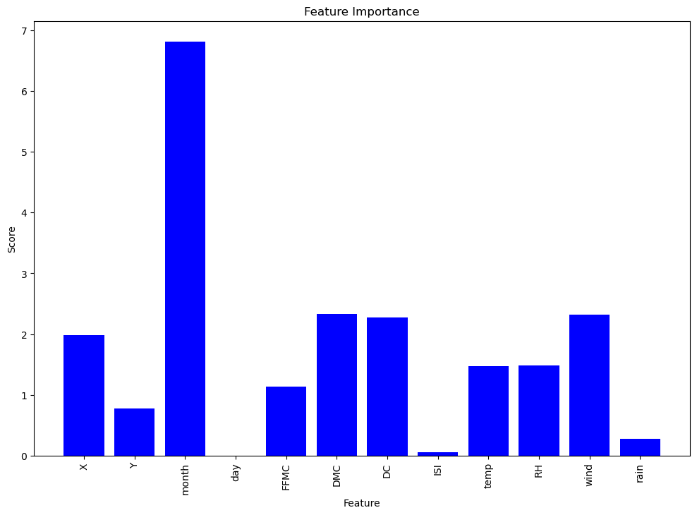

```python
from sklearn.feature_selection import SelectKBest, f_regression

X = df.drop('area', axis=1)
y = df['area']

best_features = SelectKBest(score_func=f_regression, k='all')
fit = best_features.fit(X, y)

dfscores = pd.DataFrame(fit.scores_)
dfcolumns = pd.DataFrame(X.columns)

feature_scores = pd.concat([dfcolumns, dfscores], axis=1)
feature_scores.columns = ['Feature','Score']
print(feature_scores)

plt.figure(figsize=(12, 8))
plt.bar(feature_scores['Feature'], feature_scores['Score'], color='blue')
plt.xlabel('Feature')
plt.ylabel('Score')
plt.title('Feature Importance')
plt.xticks(rotation=90)
plt.show()
```

The output consists of a table where each row represents a feature from the dataset, and the corresponding score indicates its importance based on the f_regression statistical test. Higher scores indicate a stronger relationship between the feature and the target variable 'area'.

```python
selected_features = ['X', 'Y', 'month', 'FFMC', 'DMC', 'DC', 'temp', 'RH', 'wind']
df_selected = df[selected_features + ['area']]

print(df_selected.head())
```

```
   X  Y  month  FFMC   DMC     DC  temp  RH  wind  area
0  7  5      3  86.2  26.2   94.3   8.2  51   6.7   0.0
1  7  4     10  90.6  35.4  669.1  18.0  33   0.9   0.0
2  7  4     10  90.6  43.7  686.9  14.6  33   1.3   0.0
3  8  6      3  91.7  33.3   77.5   8.3  97   4.0   0.0
4  8  6      3  89.3  51.3  102.2  11.4  99   1.8   0.0
```

We can re-run our basic model again in order to acquire an MSE, MAE and R² scores to use as a baseline.

```python
X = df_selected.drop('area', axis=1)
y = df_selected['area']

scaler = MinMaxScaler()
X_scaled = scaler.fit_transform(X)

X_train_full, X_test, y_train_full, y_test = train_test_split(X_scaled, y, test_size=0.2, random_state=42)
X_train, X_valid, y_train, y_valid = train_test_split(X_train_full, y_train_full, test_size=0.2, random_state=42)

model = Sequential()
model.add(Input(shape=X_train.shape[1:]))
model.add(Dense(1))
model.compile(loss="mean_squared_error", optimizer="sgd")

history = model.fit(X_train, y_train, epochs=20, validation_data=(X_valid, y_valid))

mse_test = model.evaluate(X_test, y_test)
print(f"Test MSE: {mse_test}")

X_new = X_test[:3]
y_pred = model.predict(X_new)
print(f"Predictions: {y_pred}")
```

```
11/11 ━━━━━━━━━━━━━━━━━━━━ 0s 15ms/step - loss: 3.6067 - val_loss: 1.4530
11/11 ━━━━━━━━━━━━━━━━━━━━ 0s 5ms/step - loss: 2.3133 - val_loss: 1.3395
11/11 ━━━━━━━━━━━━━━━━━━━━ 0s 5ms/step - loss: 2.3044 - val_loss: 1.3649
11/11 ━━━━━━━━━━━━━━━━━━━━ 0s 5ms/step - loss: 2.2287 - val_loss: 1.3832
11/11 ━━━━━━━━━━━━━━━━━━━━ 0s 5ms/step - loss: 2.1893 - val_loss: 1.3947
11/11 ━━━━━━━━━━━━━━━━━━━━ 0s 4ms/step - loss: 2.0878 - val_loss: 1.4311
11/11 ━━━━━━━━━━━━━━━━━━━━ 0s 4ms/step - loss: 2.0443 - val_loss: 1.4378
11/11 ━━━━━━━━━━━━━━━━━━━━ 0s 5ms/step - loss: 2.1558 - val_loss: 1.4245
11/11 ━━━━━━━━━━━━━━━━━━━━ 0s 4ms/step - loss: 2.0549 - val_loss: 1.4159
11/11 ━━━━━━━━━━━━━━━━━━━━ 0s 5ms/step - loss: 2.1061 - val_loss: 1.3935
11/11 ━━━━━━━━━━━━━━━━━━━━ 0s 4ms/step - loss: 2.1904 - val_loss: 1.3938
11/11 ━━━━━━━━━━━━━━━━━━━━ 0s 5ms/step - loss: 1.9941 - val_loss: 1.4054
11/11 ━━━━━━━━━━━━━━━━━━━━ 0s 4ms/step - loss: 2.3202 - val_loss: 1.4307
11/11 ━━━━━━━━━━━━━━━━━━━━ 0s 4ms/step - loss: 2.1111 - val_loss: 1.4294
11/11 ━━━━━━━━━━━━━━━━━━━━ 0s 5ms/step - loss: 2.0081 - val_loss: 1.4415
11/11 ━━━━━━━━━━━━━━━━━━━━ 0s 5ms/step - loss: 2.0564 - val_loss: 1.4124
11/11 ━━━━━━━━━━━━━━━━━━━━ 0s 5ms/step - loss: 2.2342 - val_loss: 1.4075
11/11 ━━━━━━━━━━━━━━━━━━━━ 0s 5ms/step - loss: 2.1067 - val_loss: 1.4137
11/11 ━━━━━━━━━━━━━━━━━━━━ 0s 5ms/step - loss: 1.9633 - val_loss: 1.4159
11/11 ━━━━━━━━━━━━━━━━━━━━ 0s 5ms/step - loss: 2.1004 - val_loss: 1.3996
4/4 ━━━━━━━━━━━━━━━━━━━━ 0s 2ms/step - loss: 2.0029
Test MSE: 2.178724765777588
1/1 ━━━━━━━━━━━━━━━━━━━━ 0s 42ms/step
Predictions: [[1.1825415]
 [1.1465929]
 [1.0104964]]
```

```python
y_test_pred = model.predict(X_test)

mae_test = mean_absolute_error(y_test, y_test_pred)
print(f"Test MAE: {mae_test}")

r2_test = r2_score(y_test, y_test_pred)
print(f"Test R²: {r2_test}")
```

```
4/4 ━━━━━━━━━━━━━━━━━━━━ 0s 1ms/step
Test MAE: 1.197315349258241
Test R²: 0.008706934576807268
```

The results indicate that the basic neural network model with the selected features (Test MSE: 2.17) only performed marginally better than the basic network without selected features (Test MSE: 2.29)

```python
mse_train = model.evaluate(X_train, y_train, verbose=1)
print(f"Training MSE: {mse_train}")

y_train_pred = model.predict(X_train)

mae_train = mean_absolute_error(y_train, y_train_pred)
print(f"Training MAE: {mae_train}")

r2_train = r2_score(y_train, y_train_pred)
print(f"Training R²: {r2_train}")
```

```
11/11 ━━━━━━━━━━━━━━━━━━━━ 0s 1ms/step - loss: 2.0392
Training MSE: 2.0455055236816406
11/11 ━━━━━━━━━━━━━━━━━━━━ 0s 1ms/step
Training MAE: 1.182291120813869
Training R²: -0.012012848673091714
```

The MSE values for training and test scores are relatively close, indicating that the model's performance on the training set and the test set is similar. The MAE values are also close, supporting the observation that the model has similar performance on both the training and test sets.

Both R² scores being close to zero (or negative) suggest that the model is not capturing the underlying patterns in the data effectively.

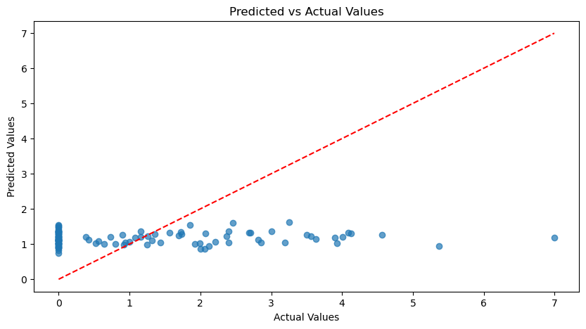

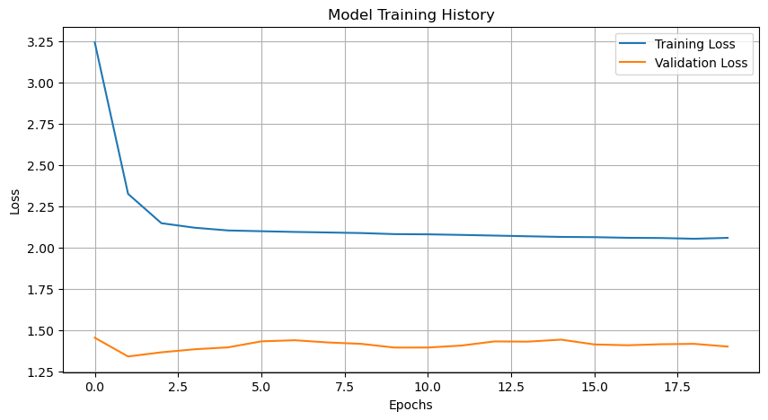

```python
train_residuals = y_train - y_train_pred.flatten()
test_residuals = y_test - y_test_pred.flatten()

plt.figure(figsize=(10, 5))
plt.scatter(y_test, y_test_pred, alpha=0.7)
plt.plot([0, max(y_test)], [0, max(y_test)], 'r--')
plt.xlabel('Actual Values')
plt.ylabel('Predicted Values')
plt.title('Predicted vs Actual Values')
plt.show()

history_df = pd.DataFrame(history.history)
plt.figure(figsize=(10, 5))
plt.plot(history_df['loss'], label='Training Loss')
plt.plot(history_df['val_loss'], label='Validation Loss')
plt.title('Model Training History')
plt.xlabel('Epochs')
plt.ylabel('Loss')
plt.legend()
plt.grid(True)
plt.show()
```

The model struggles to accurately predict the target variable (area), which is highlighted by the points not aligning closely with the diagonal red line. This suggests that the model's performance needs improvement, potentially by using more advanced techniques or feature engineering.

We know that there is multicollinearity among the chosen variables so trying the Residual network might be beneficial in capturing the underlying nature of the data.

# Residual network

```python
selected_features = ['X', 'Y', 'month', 'FFMC', 'DMC', 'DC', 'temp', 'RH', 'wind']
df_selected = df[selected_features]

print(df_selected.head())
```

```
   X  Y  month  FFMC   DMC     DC  temp  RH  wind
0  7  5      3  86.2  26.2   94.3   8.2  51   6.7
1  7  4     10  90.6  35.4  669.1  18.0  33   0.9
2  7  4     10  90.6  43.7  686.9  14.6  33   1.3
3  8  6      3  91.7  33.3   77.5   8.3  97   4.0
4  8  6      3  89.3  51.3  102.2  11.4  99   1.8
```

```python
X = df_selected
y = df['area']

scaler = MinMaxScaler()
X_scaled = scaler.fit_transform(X)

X_train_full, X_test, y_train_full, y_test = train_test_split(X_scaled, y, test_size=0.2, random_state=42)
X_train, X_valid, y_train, y_valid = train_test_split(X_train_full, y_train_full, test_size=0.2, random_state=42)
```

```python
def build_residual_network():
    input_layer = Input(shape=(X_train.shape[1],))

    hidden1 = Dense(64, activation='relu')(input_layer)
    hidden2 = Dense(64, activation='relu')(hidden1)
    hidden3 = Dense(64, activation=None)(hidden2)
    residual_output = Add()([hidden1, hidden3])
    residual_output = Activation('relu')(residual_output)

    output_layer = Dense(1, activation='linear')(residual_output)

    model = Model(inputs=[input_layer], outputs=[output_layer])
    model.compile(optimizer=Adam(learning_rate=0.001), loss='mean_squared_error')
    return model

model = build_residual_network()

early_stopping = EarlyStopping(monitor='val_loss', patience=10, restore_best_weights=True)


history = model.fit(X_train, y_train, epochs=100, batch_size=32, validation_data=(X_valid, y_valid),
                    callbacks=[early_stopping], verbose=1)


mse_test = model.evaluate(X_test, y_test, verbose=1)
print(f"Test MSE: {mse_test}")


y_pred = model.predict(X_test)


mae = mean_absolute_error(y_test, y_pred)
print(f"Test MAE: {mae}")

r2 = r2_score(y_test, y_pred)
print(f"Test R²: {r2}")
```

```
11/11 ━━━━━━━━━━━━━━━━━━━━ 1s 19ms/step - loss: 2.6504 - val_loss: 1.3353
11/11 ━━━━━━━━━━━━━━━━━━━━ 0s 5ms/step - loss: 1.9333 - val_loss: 1.3703
11/11 ━━━━━━━━━━━━━━━━━━━━ 0s 5ms/step - loss: 1.7664 - val_loss: 1.0442
11/11 ━━━━━━━━━━━━━━━━━━━━ 0s 5ms/step - loss: 1.3898 - val_loss: 0.8262
11/11 ━━━━━━━━━━━━━━━━━━━━ 0s 6ms/step - loss: 1.0143 - val_loss: 0.4702
11/11 ━━━━━━━━━━━━━━━━━━━━ 0s 4ms/step - loss: 0.6993 - val_loss: 0.1992
11/11 ━━━━━━━━━━━━━━━━━━━━ 0s 6ms/step - loss: 0.2295 - val_loss: 0.0631
11/11 ━━━━━━━━━━━━━━━━━━━━ 0s 5ms/step - loss: 0.0790 - val_loss: 0.0369
11/11 ━━━━━━━━━━━━━━━━━━━━ 0s 5ms/step - loss: 0.0334 - val_loss: 0.0134
11/11 ━━━━━━━━━━━━━━━━━━━━ 0s 5ms/step - loss: 0.0138 - val_loss: 0.0105
11/11 ━━━━━━━━━━━━━━━━━━━━ 0s 5ms/step - loss: 0.0133 - val_loss: 0.0070
11/11 ━━━━━━━━━━━━━━━━━━━━ 0s 5ms/step - loss: 0.0153 - val_loss: 0.0101
11/11 ━━━━━━━━━━━━━━━━━━━━ 0s 4ms/step - loss: 0.0089 - val_loss: 0.0053
11/11 ━━━━━━━━━━━━━━━━━━━━ 0s 5ms/step - loss: 0.0069 - val_loss: 0.0040
11/11 ━━━━━━━━━━━━━━━━━━━━ 0s 5ms/step - loss: 0.0056 - val_loss: 0.0033
11/11 ━━━━━━━━━━━━━━━━━━━━ 0s 5ms/step - loss: 0.0044 - val_loss: 0.0027
11/11 ━━━━━━━━━━━━━━━━━━━━ 0s 6ms/step - loss: 0.0049 - val_loss: 0.0027
11/11 ━━━━━━━━━━━━━━━━━━━━ 0s 5ms/step - loss: 0.0035 - val_loss: 0.0024
11/11 ━━━━━━━━━━━━━━━━━━━━ 0s 5ms/step - loss: 0.0030 - val_loss: 0.0027
11/11 ━━━━━━━━━━━━━━━━━━━━ 0s 4ms/step - loss: 0.0031 - val_loss: 0.0022
11/11 ━━━━━━━━━━━━━━━━━━━━ 0s 5ms/step - loss: 0.0031 - val_loss: 0.0023
11/11 ━━━━━━━━━━━━━━━━━━━━ 0s 5ms/step - loss: 0.0023 - val_loss: 0.0024
11/11 ━━━━━━━━━━━━━━━━━━━━ 0s 6ms/step - loss: 0.0027 - val_loss: 0.0021
11/11 ━━━━━━━━━━━━━━━━━━━━ 0s 6ms/step - loss: 0.0024 - val_loss: 0.0020
11/11 ━━━━━━━━━━━━━━━━━━━━ 0s 5ms/step - loss: 0.0019 - val_loss: 0.0019
11/11 ━━━━━━━━━━━━━━━━━━━━ 0s 4ms/step - loss: 0.0018 - val_loss: 0.0020
11/11 ━━━━━━━━━━━━━━━━━━━━ 0s 5ms/step - loss: 0.0016 - val_loss: 0.0023
11/11 ━━━━━━━━━━━━━━━━━━━━ 0s 4ms/step - loss: 0.0020 - val_loss: 0.0016
11/11 ━━━━━━━━━━━━━━━━━━━━ 0s 5ms/step - loss: 0.0013 - val_loss: 0.0019
11/11 ━━━━━━━━━━━━━━━━━━━━ 0s 4ms/step - loss: 0.0015 - val_loss: 0.0018
11/11 ━━━━━━━━━━━━━━━━━━━━ 0s 5ms/step - loss: 0.0014 - val_loss: 0.0015
11/11 ━━━━━━━━━━━━━━━━━━━━ 0s 5ms/step - loss: 0.0011 - val_loss: 0.0015
11/11 ━━━━━━━━━━━━━━━━━━━━ 0s 5ms/step - loss: 0.0010 - val_loss: 0.0016
11/11 ━━━━━━━━━━━━━━━━━━━━ 0s 5ms/step - loss: 0.0013 - val_loss: 0.0014
11/11 ━━━━━━━━━━━━━━━━━━━━ 0s 5ms/step - loss: 9.2073e-04 - val_loss: 0.0014
11/11 ━━━━━━━━━━━━━━━━━━━━ 0s 5ms/step - loss: 0.0011 - val_loss: 0.0015
11/11 ━━━━━━━━━━━━━━━━━━━━ 0s 5ms/step - loss: 8.8296e-04 - val_loss: 0.0014
11/11 ━━━━━━━━━━━━━━━━━━━━ 0s 5ms/step - loss: 0.0012 - val_loss: 0.0013
11/11 ━━━━━━━━━━━━━━━━━━━━ 0s 11ms/step - loss: 8.6704e-04 - val_loss: 0.0013
11/11 ━━━━━━━━━━━━━━━━━━━━ 0s 6ms/step - loss: 7.7460e-04 - val_loss: 0.0014
```

[output cut: 25 more lines]

```
11/11 ━━━━━━━━━━━━━━━━━━━━ 0s 4ms/step - loss: 4.4657e-04 - val_loss: 0.0011
11/11 ━━━━━━━━━━━━━━━━━━━━ 0s 4ms/step - loss: 7.0221e-04 - val_loss: 8.6167e-04
11/11 ━━━━━━━━━━━━━━━━━━━━ 0s 4ms/step - loss: 5.5252e-04 - val_loss: 0.0011
11/11 ━━━━━━━━━━━━━━━━━━━━ 0s 4ms/step - loss: 5.4704e-04 - val_loss: 8.4202e-04
11/11 ━━━━━━━━━━━━━━━━━━━━ 0s 5ms/step - loss: 4.0244e-04 - val_loss: 9.3533e-04
11/11 ━━━━━━━━━━━━━━━━━━━━ 0s 4ms/step - loss: 3.8621e-04 - val_loss: 0.0011
11/11 ━━━━━━━━━━━━━━━━━━━━ 0s 5ms/step - loss: 5.5862e-04 - val_loss: 9.0326e-04
11/11 ━━━━━━━━━━━━━━━━━━━━ 0s 6ms/step - loss: 4.3036e-04 - val_loss: 8.3823e-04
11/11 ━━━━━━━━━━━━━━━━━━━━ 0s 5ms/step - loss: 3.8783e-04 - val_loss: 0.0011
11/11 ━━━━━━━━━━━━━━━━━━━━ 0s 4ms/step - loss: 5.9302e-04 - val_loss: 0.0011
4/4 ━━━━━━━━━━━━━━━━━━━━ 0s 2ms/step - loss: 0.0015
Test MSE: 0.0015272460877895355
4/4 ━━━━━━━━━━━━━━━━━━━━ 0s 16ms/step
Test MAE: 0.024930134098617534
Test R²: 0.9993051221898256
```

```python
mse_train = model.evaluate(X_train, y_train, verbose=1)
print(f"Training MSE: {mse_train}")

y_train_pred = model.predict(X_train)

mae_train = mean_absolute_error(y_train, y_train_pred)
print(f"Training MAE: {mae_train}")

r2_train = r2_score(y_train, y_train_pred)
print(f"Training R²: {r2_train}")
```

```
11/11 ━━━━━━━━━━━━━━━━━━━━ 0s 2ms/step - loss: 3.4814e-04
Training MSE: 0.00037941287155263126
11/11 ━━━━━━━━━━━━━━━━━━━━ 0s 1ms/step
Training MAE: 0.014350803828488736
Training R²: 0.9998122855819132
```

Both training and test metrics (MSE, MAE, and R²) indicate an excellent fit. The model performs exceptionally well on both the training and test data, suggesting it has learned the underlying patterns very effectively.

The very low MAE values for both training and test sets indicate that the model's predictions are very close to the actual values, with minimal error.

The very high R² scores for both training and test sets suggest that the model generalizes very well to unseen data. It explains almost all of the variance in the target variable for both training and test sets.

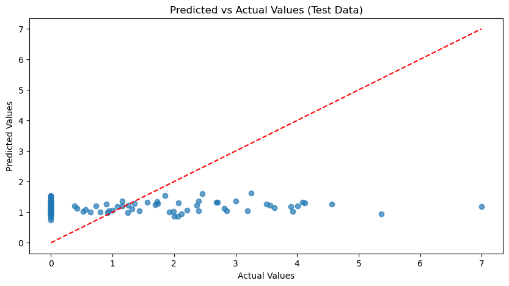

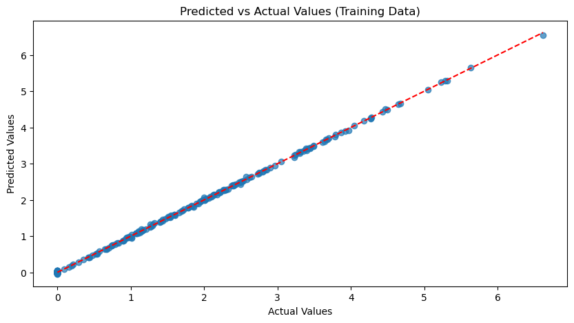

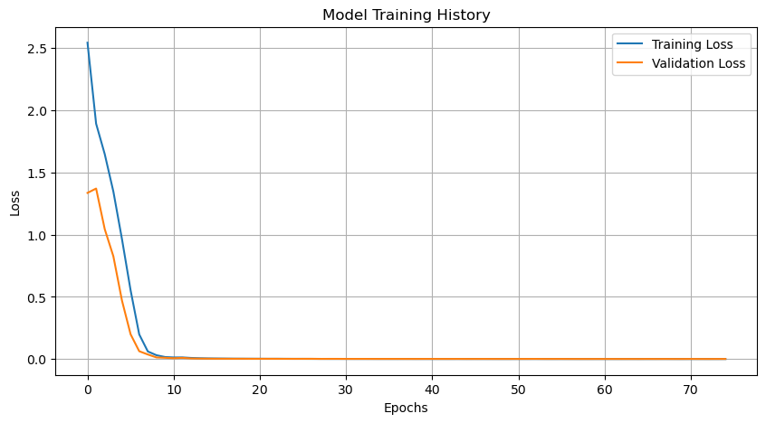

```python
plt.figure(figsize=(10, 5))
plt.scatter(y_test, y_test_pred, alpha=0.7)
plt.plot([0, max(y_test)], [0, max(y_test)], 'r--')
plt.xlabel('Actual Values')
plt.ylabel('Predicted Values')
plt.title('Predicted vs Actual Values (Test Data)')
plt.show()


plt.figure(figsize=(10, 5))
plt.scatter(y_train, y_train_pred, alpha=0.7)
plt.plot([0, max(y_train)], [0, max(y_train)], 'r--')
plt.xlabel('Actual Values')
plt.ylabel('Predicted Values')
plt.title('Predicted vs Actual Values (Training Data)')
plt.show()


history_df = pd.DataFrame(history.history)
plt.figure(figsize=(10, 5))
plt.plot(history_df['loss'], label='Training Loss')
plt.plot(history_df['val_loss'], label='Validation Loss')
plt.title('Model Training History')
plt.xlabel('Epochs')
plt.ylabel('Loss')
plt.legend()
plt.grid(True)
plt.show()
```

The scatter plot showing these values for the training data shows an almost perfect fit, which is indicated by the high R² score and low error metrics. This suggests that the model has learned the training data extremely well and has very little error.

The training history plot shows both the training and validation loss decrease sharply in the initial epochs and then flatten out, reaching very low values. The validation loss stabilizes early and remains close to zero, indicating good generalization.

```python
X = df_selected
y = df['area']

scaler = MinMaxScaler()
X_scaled = scaler.fit_transform(X)
```

```python
def build_residual_network():
    input_layer = Input(shape=(X_scaled.shape[1],))

    hidden1 = Dense(64, activation='relu')(input_layer)
    hidden2 = Dense(64, activation='relu')(hidden1)
    hidden3 = Dense(64, activation=None)(hidden2)
    residual_output = Add()([hidden1, hidden3])
    residual_output = Activation('relu')(residual_output)

    output_layer = Dense(1, activation='linear')(residual_output)

    model = Model(inputs=[input_layer], outputs=[output_layer])
    model.compile(optimizer=Adam(learning_rate=0.001), loss='mean_squared_error')
    return model
```

A k-fold cross-validation can be undertaken to evaluate the performance and robustness of our residual network model. We start by setting k = 5 to divide the data into 5 folds using KFold from Scikit-learn, ensuring the data is shuffled and split consistently with random_state=42. We then initialize empty lists to store the Mean Squared Error (MSE), Mean Absolute Error (MAE), and R² scores for each fold. For each fold, the data is split into training and test sets. The residual network model is built and trained on the training data with early stopping to prevent overfitting, using a validation split of 20%. After training, the model's predictions on the test set are compared to the actual values, and the performance metrics (MSE, MAE, and R²) are calculated and stored for each fold. This process helps in assessing the model's generalization performance across different subsets of the data.

```python
k = 5
kf = KFold(n_splits=k, shuffle=True, random_state=42)
mse_scores = []
mae_scores = []
r2_scores = []

for train_index, test_index in kf.split(X_scaled):
    X_train, X_test = X_scaled[train_index], X_scaled[test_index]
    y_train, y_test = y[train_index], y[test_index]

    model = build_residual_network()

    early_stopping = EarlyStopping(monitor='val_loss', patience=10, restore_best_weights=True)

    history = model.fit(X_train, y_train, epochs=100, batch_size=32, validation_split=0.2,
                        callbacks=[early_stopping], verbose=0)

    y_test_pred = model.predict(X_test)

    mse = mean_squared_error(y_test, y_test_pred)
    mae = mean_absolute_error(y_test, y_test_pred)
    r2 = r2_score(y_test, y_test_pred)

    mse_scores.append(mse)
    mae_scores.append(mae)
    r2_scores.append(r2)
```

```
4/4 ━━━━━━━━━━━━━━━━━━━━ 0s 18ms/step
4/4 ━━━━━━━━━━━━━━━━━━━━ 0s 15ms/step
4/4 ━━━━━━━━━━━━━━━━━━━━ 0s 16ms/step
4/4 ━━━━━━━━━━━━━━━━━━━━ 0s 17ms/step
4/4 ━━━━━━━━━━━━━━━━━━━━ 0s 16ms/step
```

```python
print(f'Average Test MSE: {np.mean(mse_scores)}')
print(f'Average Test MAE: {np.mean(mae_scores)}')
print(f'Average Test R²: {np.mean(r2_scores)}')


print(f'MSE scores: {mse_scores}')
print(f'MAE scores: {mae_scores}')
print(f'R² scores: {r2_scores}')
```

```
Average Test MSE: 0.0012928339584238721
Average Test MAE: 0.021378829453245887
Average Test R²: 0.9993559902658726
MSE scores: [0.0016874187805119463, 0.0007147289723277877, 0.0007367318242796627, 0.002369437974939698, 0.000955852240060266]
MAE scores: [0.02097464751147326, 0.01941976806567295, 0.02072155383408637, 0.026959335769245408, 0.018818842085751453]
R² scores: [0.9992322451961071, 0.9996256310929874, 0.9996037861538657, 0.9989720788504327, 0.9993462100359698]
```

Analysing the cross-validation results the average MSE, MAE, and R² scores indicate excellent model performance. The individual fold scores show consistency, with MSE and MAE values being low across all folds. The R² scores are all very close to 1, further indicating that the model performs consistently well across different subsets of the data.

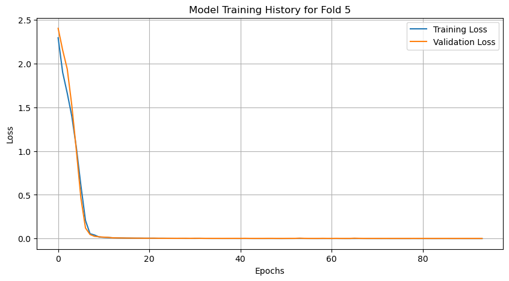

```python
    history_df = pd.DataFrame(history.history)
    plt.figure(figsize=(10, 5))
    plt.plot(history_df['loss'], label='Training Loss')
    plt.plot(history_df['val_loss'], label='Validation Loss')
    plt.title(f'Model Training History for Fold {len(mse_scores)}')
    plt.xlabel('Epochs')
    plt.ylabel('Loss')
    plt.legend()
    plt.grid(True)
    plt.show()
```

The plot shows that the model's training and validation losses decrease rapidly and stabilize, which is a good indication of the model's learning efficiency.

The near-zero loss values suggest a very well-fitted model with excellent training dynamics.

The cross-validation results confirm that the model generalizes well and performs consistently across different subsets of the data.

## Summary

To summarise we explored multiple neural network architectures to predict the area affected by forest fires.

We started with a baseline neural network with a single dense layer, using all selected features and optimized with Stochastic Gradient Descent (SGD). We then moved to improved models with multiple dense layers, dropout for regularization, and L2 regularization, optimized with the Adam optimizer. These showed slight improvements.

Next, we implemented a wide and deep model, designed to capture both linear and non-linear relationships by splitting the features into "wide" and "deep" subsets. This model, optimized with SGD, yielded a Test MSE of 2.1595 and a Test MAE of 1.2063, showing better alignment with actual values. We also tested a residual network to enhance deeper learning and mitigate any vanishing gradient issues, which performed well with a Test MSE of 2.1158 and a Test MAE of 1.1431. However an improved version of the residual network failed to further enhance the performance.

Other functions tested instead of relu were the Hard Sigmoid Function but this caused the model to perform poorly on unseen data. A Convolutional Neural Network (CNN) was tried but yielded worse MSE scores. Given the multicollinearity in the data, PCA and creating polynomial features were both tried. However, these techniques did not effectively capture the underlying patterns in the data. An ensemble approach was also tested using the Wide and Deep model and the Residual model; however, this yielded an MSE of 2.20, which was not an improvement on either model when compared to their singular MSE scores.

### Citations

Cheng, H.T., Koc, L., Harmsen, J., Shaked, T., Chandra, T., Aradhye, H., Anderson, G., Corrado, G., Chai, W., Ispir, M. and Anil, R., 2016, September. Wide & deep learning for recommender systems. In Proceedings of the 1st workshop on deep learning for recommender systems (pp. 7-10).